# Time-varying coefficients model using GAMs

We are going to use *generalized additive models* (GAMs) to estimate time-varying coefficients for climate variables in order to quantify their effects on malaria incidence by specie thought the time period of the study.

First, lets load some packages to handle the tasks we are going to do.

```r
# Utilities
library(tictoc)

# Data loading
library(readr)
library(skimr)

# Data manipulation
library(tibble)
library(lubridate)
library(dplyr)
library(splitTools)
library(scales)
library(DT)
library(htmltools)
library(stringr)

# Plots
library(ggplot2)
ggplot2::theme_set(theme_bw())
ggplot2::theme_update(panel.grid = element_blank())
library(ggsci)

# GAM
library(mgcv)
library(gratia)
```

# Data wrangling

## Loading

The cleaned up data can be found on the `~/data/processed/` directory on this repository. Define the file path to read the data.

```r
processed_data_path <- file.path("../data/processed/")
file_name           <- "pro_malaria-monthly-cases-district-loreto"
file                <- paste(file_name, ".csv", sep = "")
file_path           <- file.path(processed_data_path, file)
```

Create a variable containing the column names for the data.

```r
col_names <- c(
  "district",
  "year",
  "month",
  "falciparum",
  "vivax",
  "aet",
  "prcp",
  "q",
  "soilm",
  "tmax",
  "tmin",
  "pop2015",
  "province",
  "region",
  "dttm",
  "time"
)
```

Define column types to optimize the parsing. We exclude `soilm` and `region` for the analysis.

```r
# Column types
col_types <-
  readr::cols_only(
    district      = col_character(),
    year          = col_integer(),
    month         = col_integer(),
    falciparum    = col_integer(),
    vivax         = col_integer(),
    aet           = col_double(),
    prcp          = col_double(),
    q             = col_double(),
    tmax          = col_double(),
    tmin          = col_double(),
    pop2015       = col_integer(),
    province      = col_character(),
    dttm          = col_datetime(),
    time          = col_integer()
  )
```

Reading csv. file into a data frame.

```r
df_malaria_loreto <-
  readr::read_csv(
    file      = file_path,
    col_names = col_names,
    col_types = col_types,
    skip      = 1,
    locale    = readr::locale(encoding = "UTF-8")
  )
```

## Parsing

We are going to parse `district`, `province`, `year` and `month` as factors.

```r
to_factor <- c("year", "month", "district", "province")

for (col in to_factor) {
  df_malaria_loreto[[col]] <- factor(df_malaria_loreto[[col]])
}
```

## Validation

Check data structure.

```r
str(df_malaria_loreto)
```

```
## tibble [10,584 x 14] (S3: spec_tbl_df/tbl_df/tbl/data.frame)
##  $ district  : Factor w/ 49 levels "ALTO NANAY","ALTO TAPICHE",..: 1 1 1 1 1 1 1 1 1 1 ...
##  $ year      : Factor w/ 18 levels "2000","2001",..: 1 1 1 1 1 1 1 1 1 1 ...
##  $ month     : Factor w/ 12 levels "1","2","3","4",..: 1 2 3 4 5 6 7 8 9 10 ...
##  $ falciparum: int [1:10584] 2 2 2 0 3 1 2 11 6 12 ...
##  $ vivax     : int [1:10584] 42 40 21 3 15 0 4 1 2 4 ...
##  $ aet       : num [1:10584] 90.8 82.1 66.8 61.8 70 ...
##  $ prcp      : num [1:10584] 227 278 358 334 380 ...
##  $ q         : num [1:10584] 136 196 291 272 310 ...
##  $ tmax      : num [1:10584] 31 31 30.4 30 30 ...
##  $ tmin      : num [1:10584] 21.7 21.5 21.3 20.8 21.3 ...
##  $ pop2015   : int [1:10584] 2784 2784 2784 2784 2784 2784 2784 2784 2784 2784 ...
##  $ province  : Factor w/ 8 levels "ALTO AMAZONAS",..: 5 5 5 5 5 5 5 5 5 5 ...
##  $ dttm      : POSIXct[1:10584], format: "2000-01-01" "2000-02-01" ...
##  $ time      : int [1:10584] 946684800 949363200 951868800 954547200 957139200 959817600 962409600 965088000 967766400 970358400 ...
##  - attr(*, "spec")=
##   .. cols_only(
##   ..   district = col_character(),
##   ..   year = col_integer(),
##   ..   month = col_integer(),
##   ..   falciparum = col_integer(),
##   ..   vivax = col_integer(),
##   ..   aet = col_double(),
##   ..   prcp = col_double(),
##   ..   q = col_double(),
##   ..   soilm = col_skip(),
##   ..   tmax = col_double(),
##   ..   tmin = col_double(),
##   ..   pop2015 = col_integer(),
##   ..   province = col_character(),
##   ..   region = col_skip(),
##   ..   dttm = col_datetime(format = ""),
##   ..   time = col_integer()
##   .. )
```

To display a summary of the data, we first define a variable containing a table with summary statistics for each data type in the data frame using the `skim` function in the `skimr` package.

```r
skim_malaria <- skimr::skim(df_malaria_loreto)
```

Then, we display the summary tables for each data type using the `yank` function of the same package:

- Factors:

```r
skimr::yank(skim_malaria, "factor")
```

**Variable type: factor**

| skim_variable | n_missing | complete_rate | ordered | n_unique | top_counts |
| --- | --- | --- | --- | --- | --- |
| district | 0 | 1 | FALSE | 49 | ALT: 216, ALT: 216, BAL: 216, BAR: 216 |
| year | 0 | 1 | FALSE | 18 | 200: 588, 200: 588, 200: 588, 200: 588 |
| month | 0 | 1 | FALSE | 12 | 1: 882, 2: 882, 3: 882, 4: 882 |
| province | 0 | 1 | FALSE | 8 | MAY: 2376, REQ: 2376, ALT: 1296, UCA: 1296 |

- Numeric:

```r
skimr::yank(skim_malaria, "numeric")
```

**Variable type: numeric**

| skim_variable | n_missing | complete_rate | mean | sd | p0 | p25 | p50 | p75 | p100 | hist |
| --- | --- | --- | --- | --- | --- | --- | --- | --- | --- | --- |
| falciparum | 0 | 1 | 1.576000e+01 | 50.88 | 0.00 | 0.000000e+00 | 0.000000e+00 | 1.000000e+01 | 1.240000e+03 | ▇▁▁▁▁ |
| vivax | 0 | 1 | 5.018000e+01 | 121.77 | 0.00 | 0.000000e+00 | 8.000000e+00 | 4.400000e+01 | 1.936000e+03 | ▇▁▁▁▁ |
| aet | 0 | 1 | 8.314000e+01 | 11.78 | 42.22 | 7.434000e+01 | 8.204000e+01 | 9.163000e+01 | 1.183400e+02 | ▁▃▇▅▁ |
| prcp | 0 | 1 | 2.229800e+02 | 112.00 | 14.13 | 1.445600e+02 | 2.041500e+02 | 2.807300e+02 | 8.110900e+02 | ▆▇▂▁▁ |
| q | 0 | 1 | 1.398400e+02 | 113.94 | 0.71 | 5.249000e+01 | 1.195000e+02 | 1.990600e+02 | 7.390900e+02 | ▇▅▁▁▁ |
| tmax | 0 | 1 | 3.143000e+01 | 1.12 | 26.90 | 3.070000e+01 | 3.144000e+01 | 3.217000e+01 | 3.514000e+01 | ▁▂▇▅▁ |
| tmin | 0 | 1 | 2.141000e+01 | 0.83 | 17.78 | 2.092000e+01 | 2.151000e+01 | 2.195000e+01 | 2.501000e+01 | ▁▂▇▂▁ |
| pop2015 | 0 | 1 | 2.121167e+04 | 32481.69 | 690.00 | 6.017000e+03 | 1.074500e+04 | 1.706100e+04 | 1.546960e+05 | ▇▁▁▁▁ |
| time | 0 | 1 | 1.229362e+09 | 163983470.51 | 946684800.00 | 1.087992e+09 | 1.229429e+09 | 1.370693e+09 | 1.512086e+09 | ▇▇▇▇▇ |

- Datetime:

```r
skimr::yank(skim_malaria, "POSIXct")
```

**Variable type: POSIXct**

| skim_variable | n_missing | complete_rate | min | max | median | n_unique |
| --- | --- | --- | --- | --- | --- | --- |
| dttm | 0 | 1 | 2000-01-01 | 2017-12-01 | 2008-12-16 12:00:00 | 216 |

## Feature engineering

Create a copy of the data frame where we are going to transform and create some new columns.

```r
dat <- tibble::tibble(df_malaria_loreto)
```

### Scaling

First, we are going to scale all climate variables from 0 to 1. The aim of this step is to avoid numerical problems in the GAM fitting procedures, and also to have a common scale on the coefficients.

```r
to_scale <- c("aet", "prcp", "q", "soilm", "tmax", "tmin")

for (col in to_scale) {
  dat[[col]] <- scales::rescale(df_malaria_loreto[[col]], to = c(0, 1))
}
```

### Lagged variables

Lagged variables are going to be used to build *distributed lag models* (DLM). In order to properly create lagged variables for this data set, first we are going to group the data by districts. Next, we arrange the data in each group by date. Finally, la `lag` function of the package `dplyr` is applied to create lagged variables by 1, 3, 6, and 12 months.

```r
dat <- dat %>%
  dplyr::group_by(district) %>%
  dplyr::arrange(dttm) %>%
  dplyr::mutate(
    aet_lag1    = dplyr::lag(aet,  n = 1L),
    aet_lag3    = dplyr::lag(aet,  n = 3L),
    aet_lag6    = dplyr::lag(aet,  n = 6L),
    aet_lag12   = dplyr::lag(aet,  n = 12L),
    prcp_lag1   = dplyr::lag(prcp, n = 1L),
    prcp_lag3   = dplyr::lag(prcp, n = 3L),
    prcp_lag6   = dplyr::lag(prcp, n = 6L),
    prcp_lag12  = dplyr::lag(prcp, n = 12L),
    q_lag1      = dplyr::lag(q,    n = 1L),
    q_lag3      = dplyr::lag(q,    n = 3L),
    q_lag6      = dplyr::lag(q,    n = 6L),
    q_lag12     = dplyr::lag(q,    n = 12L),
    soilm_lag1  = dplyr::lag(q,    n = 1L),
    soilm_lag3  = dplyr::lag(q,    n = 3L),
    soilm_lag6  = dplyr::lag(q,    n = 6L),
    soilm_lag12 = dplyr::lag(q,    n = 12L),
    tmax_lag1   = dplyr::lag(tmax, n = 1L),
    tmax_lag3   = dplyr::lag(tmax, n = 3L),
    tmax_lag6   = dplyr::lag(tmax, n = 6L),
    tmax_lag12  = dplyr::lag(tmax, n = 12L),
    tmin_lag1   = dplyr::lag(tmin, n = 1L),
    tmin_lag3   = dplyr::lag(tmin, n = 3L),
    tmin_lag6   = dplyr::lag(tmin, n = 6L),
    tmin_lag12  = dplyr::lag(tmin, n = 12L)
  )
```

Since `NA` values are going to be present for the first 12 months (because of the 12 month lagged variables), we have to do a filter.

```r
dat <- na.omit(dat)
```

Finally, we create a column containing the values of the districts’ population on the natural logarithmic scale.

```r
dat$ln_pop2015 <- log(dat$pop2015)
```

Display the final data frame for checking.

```r
dat
```

```
## # A tibble: 9,996 x 39
## # Groups:   district [49]
##    district year  month falciparum vivax   aet  prcp      q  tmax  tmin pop2015
##    <fct>    <fct> <fct>      <int> <int> <dbl> <dbl>  <dbl> <dbl> <dbl>   <int>
##  1 ALTO NA~ 2001  1              6     2 0.214 0.414 0.386  0.387 0.411    2784
##  2 ALTO TA~ 2001  1              0     0 0.295 0.217 0.164  0.495 0.382    2106
##  3 BALSAPU~ 2001  1             39    43 0.359 0.153 0.0896 0.285 0.262   17436
##  4 BARRANCA 2001  1              9    21 0.362 0.180 0.118  0.296 0.295   13608
##  5 BELEN    2001  1              1    37 0.163 0.498 0.481  0.408 0.397   75685
##  6 CAHUAPA~ 2001  1             27     2 0.351 0.167 0.105  0.328 0.359    8331
##  7 CAPELO   2001  1              0     0 0.200 0.301 0.265  0.509 0.428    4454
##  8 CONTAMA~ 2001  1              0     0 0.523 0.183 0.104  0.609 0.366   27273
##  9 EMILIO ~ 2001  1              2     3 0.285 0.228 0.177  0.551 0.436    7488
## 10 FERNAND~ 2001  1              1     9 0.162 0.471 0.452  0.404 0.393   20225
## # ... with 9,986 more rows, and 28 more variables: province <fct>, dttm <dttm>,
## #   time <int>, aet_lag1 <dbl>, aet_lag3 <dbl>, aet_lag6 <dbl>,
## #   aet_lag12 <dbl>, prcp_lag1 <dbl>, prcp_lag3 <dbl>, prcp_lag6 <dbl>,
## #   prcp_lag12 <dbl>, q_lag1 <dbl>, q_lag3 <dbl>, q_lag6 <dbl>, q_lag12 <dbl>,
## #   soilm_lag1 <dbl>, soilm_lag3 <dbl>, soilm_lag6 <dbl>, soilm_lag12 <dbl>,
## #   tmax_lag1 <dbl>, tmax_lag3 <dbl>, tmax_lag6 <dbl>, tmax_lag12 <dbl>,
## #   tmin_lag1 <dbl>, tmin_lag3 <dbl>, tmin_lag6 <dbl>, tmin_lag12 <dbl>,
## #   ln_pop2015 <dbl>
```

# Model building

Mainly, we are going to use the *Akaike information criterion* (AIC) to compare the candidate models. The AIC measures how well a model fits the data given a certain number of parameters in the model. For further examination of the models, we are going to extract a random test set of the data. The aim is to see how well the model interpolates unseen observations during the time period of the study. We are going to use the out-of-bag deviance to measure this model feature.

```r
set.seed(20210223)

indices <- splitTools::partition(
  y    = dat$district,
  type = "stratified",
  p    = c(train = 0.88, test = 0.12)
)

train <- dat[indices$train, ]
test  <- dat[indices$test, ]
```

Define function that returns the out-of-sample deviance for some model.

```r
# TODO Cite authors
get_oos_dev <- function(model, prediction, y, weights = NULL) {

  if(is.null(weights)) weights <- rep(1, times= length(y))

  dev_residuals <- model$family$dev.resids(y, prediction, weights)
  deviance      <- sum(dev_residuals)
  deviance
}
```

## TVCM: Model 0

Predictors: `aet`, `prcp`, `q`, `tmax`, `tmin`

### P. vivax

```r
tictoc::tic("GAM model fitting")
vivax_tvcm_0 <- mgcv::bam(
  formula =
    vivax ~
    offset(ln_pop2015) +
    s(district, bs = "re", k = 49) +
    s(time, by = aet,   bs = "tp", k = 50) +
    s(time, by = prcp,  bs = "tp", k = 30) +
    s(time, by = q,     bs = "tp", k = 30) +
    s(time, by = tmax,  bs = "tp", k = 100) +
    s(time, by = tmin,  bs = "tp", k = 100),
  family   = nb(),
  data     = train,
  method   = "fREML",
  discrete = TRUE
)
tictoc::toc()
```

```
## GAM model fitting: 2.91 sec elapsed
```

```r
cat("\nConverged?", vivax_tvcm_0$converged, "\n")
```

```
##
## Converged? TRUE
```

```r
mgcv::summary.gam(vivax_tvcm_0)
```

```
##
## Family: Negative Binomial(0.904)
## Link function: log
##
## Formula:
## vivax ~ offset(ln_pop2015) + s(district, bs = "re", k = 49) +
##     s(time, by = aet, bs = "tp", k = 50) + s(time, by = prcp,
##     bs = "tp", k = 30) + s(time, by = q, bs = "tp", k = 30) +
##     s(time, by = tmax, bs = "tp", k = 100) + s(time, by = tmin,
##     bs = "tp", k = 100)
##
## Parametric coefficients:
##             Estimate Std. Error t value Pr(>|t|)
## (Intercept)  -6.1797     0.3393  -18.21   <2e-16 ***
## ---
## Signif. codes:  0 '***' 0.001 '**' 0.01 '*' 0.05 '.' 0.1 ' ' 1
##
## Approximate significance of smooth terms:
##                 edf Ref.df       F p-value
## s(district)  47.799 49.000 237.783 < 2e-16 ***
## s(time):aet  15.223 18.312   6.103 < 2e-16 ***
## s(time):prcp  5.236  6.267   3.111 0.00427 **
## s(time):q     2.002  2.002   1.559 0.21047
## s(time):tmax 62.296 74.647  10.791 < 2e-16 ***
## s(time):tmin 17.889 21.680  13.471 < 2e-16 ***
## ---
## Signif. codes:  0 '***' 0.001 '**' 0.01 '*' 0.05 '.' 0.1 ' ' 1
##
## R-sq.(adj) =  0.433   Deviance explained = 69.8%
## fREML =  13036  Scale est. = 1         n = 8775
```

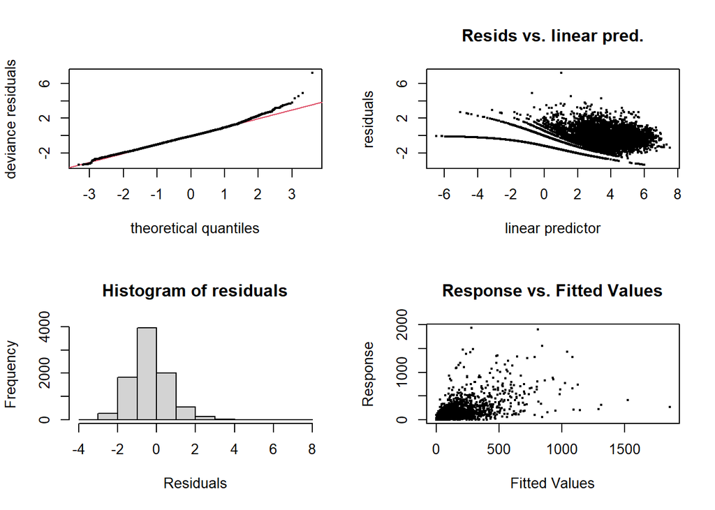

```
##
## Method: fREML   Optimizer: perf chol
## $grad
## [1]  2.138819e-06 -1.118541e-05 -5.279032e-04 -8.550158e-05 -3.760257e-05
## [6]  9.419929e-06
##
## $hess
##               [,1]          [,2]          [,3]          [,4]          [,5]
## [1,]  2.326349e+01 -2.737544e-02 -0.0004473111 -2.386291e-06 -3.397299e-01
## [2,] -2.737544e-02  1.396974e+00  0.0108970020  1.008619e-05  6.237170e-01
## [3,] -4.473111e-04  1.089700e-02  1.2630150777  5.404875e-04  1.255979e-01
## [4,] -2.386291e-06  1.008619e-05  0.0005404875  8.571479e-05  3.498964e-05
## [5,] -3.397299e-01  6.237170e-01  0.1255979179  3.498964e-05  1.546777e+01
## [6,]  2.166821e-03  5.391228e-01 -0.0136364159 -1.090589e-05  5.891796e-01
##               [,6]
## [1,]  2.166821e-03
## [2,]  5.391228e-01
## [3,] -1.363642e-02
## [4,] -1.090589e-05
## [5,]  5.891796e-01
## [6,]  2.904940e+00
##
## Model rank =  360 / 360
##
## Basis dimension (k) checking results. Low p-value (k-index<1) may
## indicate that k is too low, especially if edf is close to k'.
##
##                  k'    edf k-index p-value
## s(district)   49.00  47.80      NA      NA
## s(time):aet   50.00  15.22    0.89    0.66
## s(time):prcp  30.00   5.24    0.89    0.61
## s(time):q     30.00   2.00    0.89    0.66
## s(time):tmax 100.00  62.30    0.89    0.66
## s(time):tmin 100.00  17.89    0.89    0.66
```

```r
par(mfrow = c(2, 2))
mgcv::gam.check(vivax_tvcm_0, pch = 19, cex = 0.3)
```

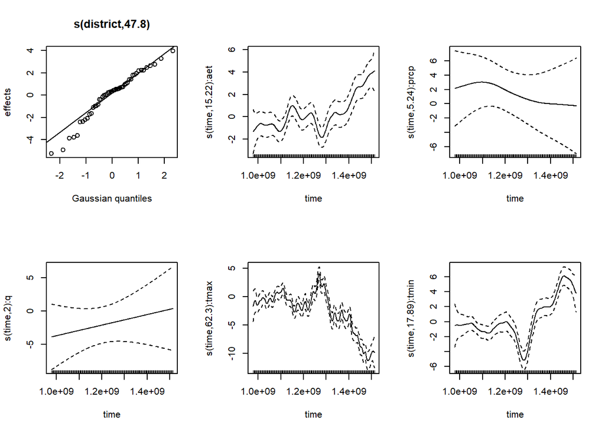

```r
mgcv::plot.gam(
  x          = vivax_tvcm_0,
  n          = 500,
  seWithMean = TRUE,
  scale      = 0,
  pages      = 1
)
```

```r
mgcv::concurvity(vivax_tvcm_0)
```

```
##          para s(district) s(time):aet s(time):prcp s(time):q s(time):tmax
## worst       1  1.00000000   0.9991610    0.9999315 0.9998673    0.9965930
## observed    1  0.39931646   0.9941275    0.9991166 0.9984703    0.9817893
## estimate    1  0.06849366   0.9933578    0.9991792 0.9985823    0.9787908
##          s(time):tmin
## worst       0.9953992
## observed    0.9772341
## estimate    0.9823724
```

```r
mgcv::concurvity(vivax_tvcm_0, full = FALSE)$estimate
```

```
##                   para s(district) s(time):aet s(time):prcp s(time):q
## para         1.0000000  0.02040821   0.3269584    0.2932024 0.2339724
## s(district)  1.0000000  1.00000000   0.3283431    0.3067379 0.2599375
## s(time):aet  0.9670981  0.02058471   1.0000000    0.8042096 0.6693608
## s(time):prcp 0.8096382  0.01782830   0.7478310    1.0000000 0.9635182
## s(time):q    0.6426163  0.01516121   0.5610824    0.9619400 1.0000000
## s(time):tmax 0.9593073  0.02165244   0.9561989    0.8177647 0.7100897
## s(time):tmin 0.9693042  0.02163550   0.9528068    0.8777772 0.7827185
##              s(time):tmax s(time):tmin
## para            0.3241488    0.3282465
## s(district)     0.3335807    0.3346828
## s(time):aet     0.9494055    0.9398439
## s(time):prcp    0.7662437    0.8522263
## s(time):q       0.5978628    0.7091171
## s(time):tmax    1.0000000    0.9522329
## s(time):tmin    0.9497181    1.0000000
```

### P. falciparum

```r
tictoc::tic("GAM model fitting")
falciparum_tvcm_0 <- mgcv::bam(
  formula =
    falciparum ~
    offset(ln_pop2015) +
    s(district, bs = "re", k = 49) +
    s(time, by = aet,   bs = "tp", k = 50) +
    s(time, by = prcp,  bs = "tp", k = 30) +
    s(time, by = q,     bs = "tp", k = 30) +
    s(time, by = tmax,  bs = "tp", k = 100) +
    s(time, by = tmin,  bs = "tp", k = 100),
  family   = nb(),
  data     = train,
  method   = "fREML",
  discrete = TRUE
)
tictoc::toc()
```

```
## GAM model fitting: 2.79 sec elapsed
```

```r
cat("\nConverged?", falciparum_tvcm_0$converged, "\n")
```

```
##
## Converged? TRUE
```

```r
mgcv::summary.gam(falciparum_tvcm_0)
```

```
##
## Family: Negative Binomial(0.529)
## Link function: log
##
## Formula:
## falciparum ~ offset(ln_pop2015) + s(district, bs = "re", k = 49) +
##     s(time, by = aet, bs = "tp", k = 50) + s(time, by = prcp,
##     bs = "tp", k = 30) + s(time, by = q, bs = "tp", k = 30) +
##     s(time, by = tmax, bs = "tp", k = 100) + s(time, by = tmin,
##     bs = "tp", k = 100)
##
## Parametric coefficients:
##             Estimate Std. Error t value Pr(>|t|)
## (Intercept)  -7.4359     0.4111  -18.09   <2e-16 ***
## ---
## Signif. codes:  0 '***' 0.001 '**' 0.01 '*' 0.05 '.' 0.1 ' ' 1
##
## Approximate significance of smooth terms:
##                 edf Ref.df       F p-value
## s(district)  47.494 49.000 148.737  <2e-16 ***
## s(time):aet   7.055  8.433   9.005  <2e-16 ***
## s(time):prcp  3.551  4.059   2.015  0.0907 .
## s(time):q     5.133  6.072   2.502  0.0192 *
## s(time):tmax 55.983 67.657   5.626  <2e-16 ***
## s(time):tmin 20.324 24.663   6.875  <2e-16 ***
## ---
## Signif. codes:  0 '***' 0.001 '**' 0.01 '*' 0.05 '.' 0.1 ' ' 1
##
## R-sq.(adj) =  0.403   Deviance explained = 66.3%
## fREML =  12117  Scale est. = 1         n = 8775
```

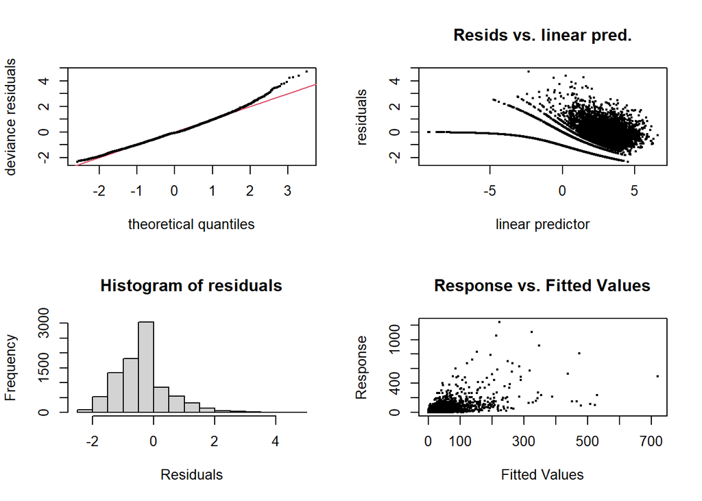

```
##
## Method: fREML   Optimizer: perf chol
## $grad
## [1] -2.123594e-08 -9.828998e-09 -1.578338e-08 -2.871240e-08 -4.382339e-07
## [6] -1.163396e-07
##
## $hess
##              [,1]         [,2]         [,3]         [,4]        [,5]
## [1,] 22.537909534 -0.009445809 -0.001443396 -0.001499270 -0.24892192
## [2,] -0.009445809  1.723845681  0.025547659 -0.057913688 -0.10060782
## [3,] -0.001443396  0.025547659  0.208806712  0.052555443 -0.01290971
## [4,] -0.001499270 -0.057913688  0.052555443  0.710642570  0.01201067
## [5,] -0.248921919 -0.100607822 -0.012909705  0.012010672 10.43926396
## [6,] -0.068198042  0.047680388 -0.003078852  0.008257267 -0.44422996
##              [,6]
## [1,] -0.068198042
## [2,]  0.047680388
## [3,] -0.003078852
## [4,]  0.008257267
## [5,] -0.444229965
## [6,]  2.581661004
##
## Model rank =  360 / 360
##
## Basis dimension (k) checking results. Low p-value (k-index<1) may
## indicate that k is too low, especially if edf is close to k'.
##
##                  k'    edf k-index p-value
## s(district)   49.00  47.49      NA      NA
## s(time):aet   50.00   7.05    0.85    0.96
## s(time):prcp  30.00   3.55    0.85    0.95
## s(time):q     30.00   5.13    0.85    0.95
## s(time):tmax 100.00  55.98    0.85    0.96
## s(time):tmin 100.00  20.32    0.85    0.96
```

```r
par(mfrow = c(2, 2))
mgcv::gam.check(falciparum_tvcm_0, pch = 19, cex = 0.3)
```

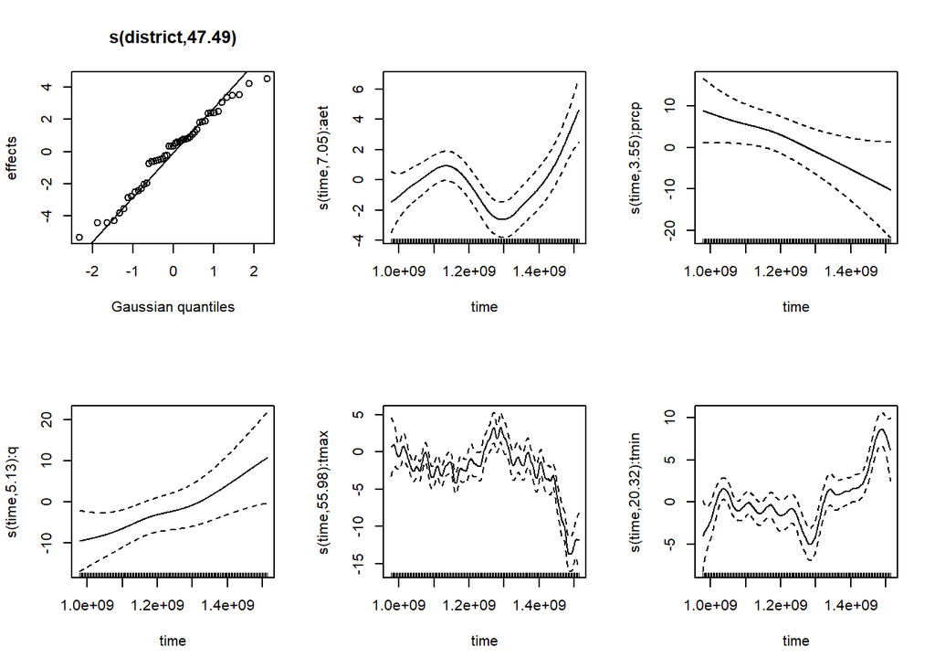

```r
mgcv::plot.gam(
  x          = falciparum_tvcm_0,
  n          = 500,
  seWithMean = TRUE,
  scale      = 0,
  pages      = 1
)
```

```r
mgcv::concurvity(falciparum_tvcm_0)
```

```
##          para s(district) s(time):aet s(time):prcp s(time):q s(time):tmax
## worst       1  1.00000000   0.9991610    0.9999315 0.9998673    0.9965930
## observed    1  0.39670200   0.9928585    0.9991426 0.9985944    0.9805096
## estimate    1  0.06849366   0.9933499    0.9991790 0.9985824    0.9789072
##          s(time):tmin
## worst       0.9953992
## observed    0.9775356
## estimate    0.9824545
```

```r
mgcv::concurvity(falciparum_tvcm_0, full = FALSE)$estimate
```

```
##                   para s(district) s(time):aet s(time):prcp s(time):q
## para         1.0000000  0.02040821   0.3315856    0.2976173 0.2376357
## s(district)  1.0000000  1.00000000   0.3329865    0.3114132 0.2640970
## s(time):aet  0.9670981  0.02058471   1.0000000    0.8038299 0.6689012
## s(time):prcp 0.8096382  0.01782830   0.7478149    1.0000000 0.9635797
## s(time):q    0.6426163  0.01516121   0.5611330    0.9619965 1.0000000
## s(time):tmax 0.9593073  0.02165244   0.9561361    0.8173983 0.7096443
## s(time):tmin 0.9693042  0.02163550   0.9527490    0.8775746 0.7824592
##              s(time):tmax s(time):tmin
## para            0.3289804    0.3331851
## s(district)     0.3385769    0.3397019
## s(time):aet     0.9493177    0.9397569
## s(time):prcp    0.7661556    0.8521904
## s(time):q       0.5978707    0.7091900
## s(time):tmax    1.0000000    0.9522017
## s(time):tmin    0.9496841    1.0000000
```

## TVCM: Model 1

Predictors: `aet`, `q`, `tmax`, `tmin`

### P. vivax

```r
tictoc::tic("GAM model fitting")
vivax_tvcm_1 <- mgcv::bam(
  formula =
    vivax ~
    offset(ln_pop2015) +
    s(district, bs = "re", k = 49) +
    s(time, by = aet,   bs = "tp", k = 50) +
    s(time, by = q,     bs = "tp", k = 30) +
    s(time, by = tmax,  bs = "tp", k = 100) +
    s(time, by = tmin,  bs = "tp", k = 100),
  family   = nb(),
  data     = train,
  method   = "fREML",
  discrete = TRUE
)
tictoc::toc()
```

```
## GAM model fitting: 2.8 sec elapsed
```

```r
cat("\nConverged?", vivax_tvcm_1$converged, "\n")
```

```
##
## Converged? TRUE
```

```r
mgcv::summary.gam(vivax_tvcm_1)
```

```
##
## Family: Negative Binomial(0.904)
## Link function: log
##
## Formula:
## vivax ~ offset(ln_pop2015) + s(district, bs = "re", k = 49) +
##     s(time, by = aet, bs = "tp", k = 50) + s(time, by = q, bs = "tp",
##     k = 30) + s(time, by = tmax, bs = "tp", k = 100) + s(time,
##     by = tmin, bs = "tp", k = 100)
##
## Parametric coefficients:
##             Estimate Std. Error t value Pr(>|t|)
## (Intercept)  -6.1323     0.3359  -18.26   <2e-16 ***
## ---
## Signif. codes:  0 '***' 0.001 '**' 0.01 '*' 0.05 '.' 0.1 ' ' 1
##
## Approximate significance of smooth terms:
##                 edf Ref.df       F  p-value
## s(district)  47.798 48.000 242.809  < 2e-16 ***
## s(time):aet  15.268 18.368   8.472  < 2e-16 ***
## s(time):q     5.197  6.221   4.258 0.000241 ***
## s(time):tmax 62.454 74.822  10.837  < 2e-16 ***
## s(time):tmin 17.885 21.676  13.571  < 2e-16 ***
## ---
## Signif. codes:  0 '***' 0.001 '**' 0.01 '*' 0.05 '.' 0.1 ' ' 1
##
## R-sq.(adj) =  0.432   Deviance explained = 69.8%
## fREML =  13039  Scale est. = 1         n = 8775
```

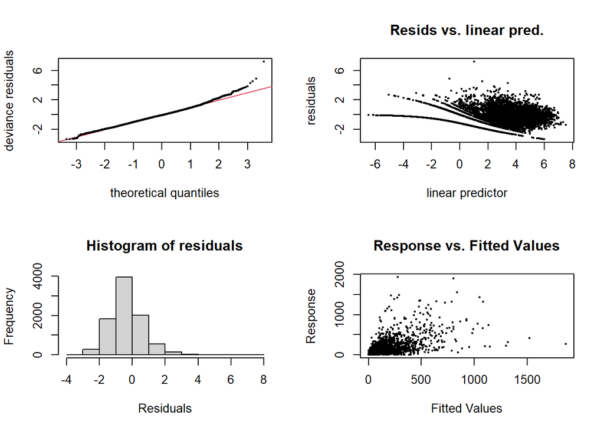

```
##
## Method: fREML   Optimizer: perf chol
## $grad
## [1]  3.129807e-08  1.782963e-07 -1.576358e-08  3.853471e-07 -6.806477e-08
##
## $hess
##               [,1]        [,2]          [,3]       [,4]         [,5]
## [1,]  2.326420e+01 -0.03201836  1.092103e-05 -0.3439472  0.003244554
## [2,] -3.201836e-02  1.45859636  1.095686e-02  0.6142002  0.536629525
## [3,]  1.092103e-05  0.01095686  1.218760e+00  0.1279887 -0.012957250
## [4,] -3.439472e-01  0.61420024  1.279887e-01 15.4420576  0.588920221
## [5,]  3.244554e-03  0.53662952 -1.295725e-02  0.5889202  2.868117359
##
## Model rank =  330 / 330
##
## Basis dimension (k) checking results. Low p-value (k-index<1) may
## indicate that k is too low, especially if edf is close to k'.
##
##                 k'   edf k-index p-value
## s(district)   49.0  47.8      NA      NA
## s(time):aet   50.0  15.3    0.89    0.73
## s(time):q     30.0   5.2    0.89    0.64
## s(time):tmax 100.0  62.5    0.89    0.66
## s(time):tmin 100.0  17.9    0.89    0.71
```

```r
par(mfrow = c(2, 2))
mgcv::gam.check(vivax_tvcm_1, pch = 19, cex = 0.3)
```

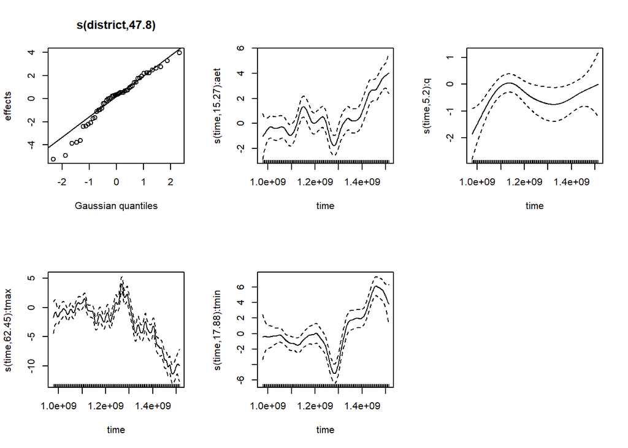

```r
mgcv::plot.gam(
  x          = vivax_tvcm_1,
  n          = 500,
  seWithMean = TRUE,
  scale      = 0,
  pages      = 1
)
```

```r
mgcv::concurvity(vivax_tvcm_1)
```

```
##          para s(district) s(time):aet s(time):q s(time):tmax s(time):tmin
## worst       1  1.00000000   0.9874232 0.9150569    0.9964767    0.9945815
## observed    1  0.39435221   0.9742755 0.8439539    0.9809818    0.9763032
## estimate    1  0.06681214   0.9761167 0.8495689    0.9778694    0.9816767
```

```r
mgcv::concurvity(vivax_tvcm_1, full = FALSE)$estimate
```

```
##                   para s(district) s(time):aet s(time):q s(time):tmax
## para         1.0000000  0.02040821   0.3271452 0.2341965    0.3242435
## s(district)  1.0000000  1.00000000   0.3285308 0.2602039    0.3336803
## s(time):aet  0.9670981  0.02058471   1.0000000 0.6692468    0.9493997
## s(time):q    0.6426163  0.01516121   0.5610422 1.0000000    0.5978359
## s(time):tmax 0.9593073  0.02165244   0.9561898 0.7099653    1.0000000
## s(time):tmin 0.9693042  0.02163550   0.9527971 0.7826439    0.9497105
##              s(time):tmin
## para            0.3283419
## s(district)     0.3347799
## s(time):aet     0.9398382
## s(time):q       0.7091004
## s(time):tmax    0.9522252
## s(time):tmin    1.0000000
```

### P. falciparum

```r
tictoc::tic("GAM model fitting")
falciparum_tvcm_1 <- mgcv::bam(
  formula =
    falciparum ~
    offset(ln_pop2015) +
    s(district, bs = "re", k = 49) +
    s(time, by = aet,   bs = "tp", k = 50) +
    s(time, by = q,     bs = "tp", k = 30) +
    s(time, by = tmax,  bs = "tp", k = 100) +
    s(time, by = tmin,  bs = "tp", k = 100),
  family   = nb(),
  data     = train,
  method   = "fREML",
  discrete = TRUE
)
tictoc::toc()
```

```
## GAM model fitting: 2.54 sec elapsed
```

```r
cat("\nConverged?", falciparum_tvcm_1$converged, "\n")
```

```
##
## Converged? TRUE
```

```r
mgcv::summary.gam(falciparum_tvcm_1)
```

```
##
## Family: Negative Binomial(0.528)
## Link function: log
##
## Formula:
## falciparum ~ offset(ln_pop2015) + s(district, bs = "re", k = 49) +
##     s(time, by = aet, bs = "tp", k = 50) + s(time, by = q, bs = "tp",
##     k = 30) + s(time, by = tmax, bs = "tp", k = 100) + s(time,
##     by = tmin, bs = "tp", k = 100)
##
## Parametric coefficients:
##             Estimate Std. Error t value Pr(>|t|)
## (Intercept)   -7.390      0.407  -18.16   <2e-16 ***
## ---
## Signif. codes:  0 '***' 0.001 '**' 0.01 '*' 0.05 '.' 0.1 ' ' 1
##
## Approximate significance of smooth terms:
##                 edf Ref.df       F p-value
## s(district)  47.492 48.000 151.774  <2e-16 ***
## s(time):aet   7.072  8.457   9.897  <2e-16 ***
## s(time):q     6.179  7.423   7.345  <2e-16 ***
## s(time):tmax 56.753 68.507   5.663  <2e-16 ***
## s(time):tmin 20.479 24.851   6.705  <2e-16 ***
## ---
## Signif. codes:  0 '***' 0.001 '**' 0.01 '*' 0.05 '.' 0.1 ' ' 1
##
## R-sq.(adj) =  0.402   Deviance explained = 66.3%
## fREML =  12122  Scale est. = 1         n = 8775
```

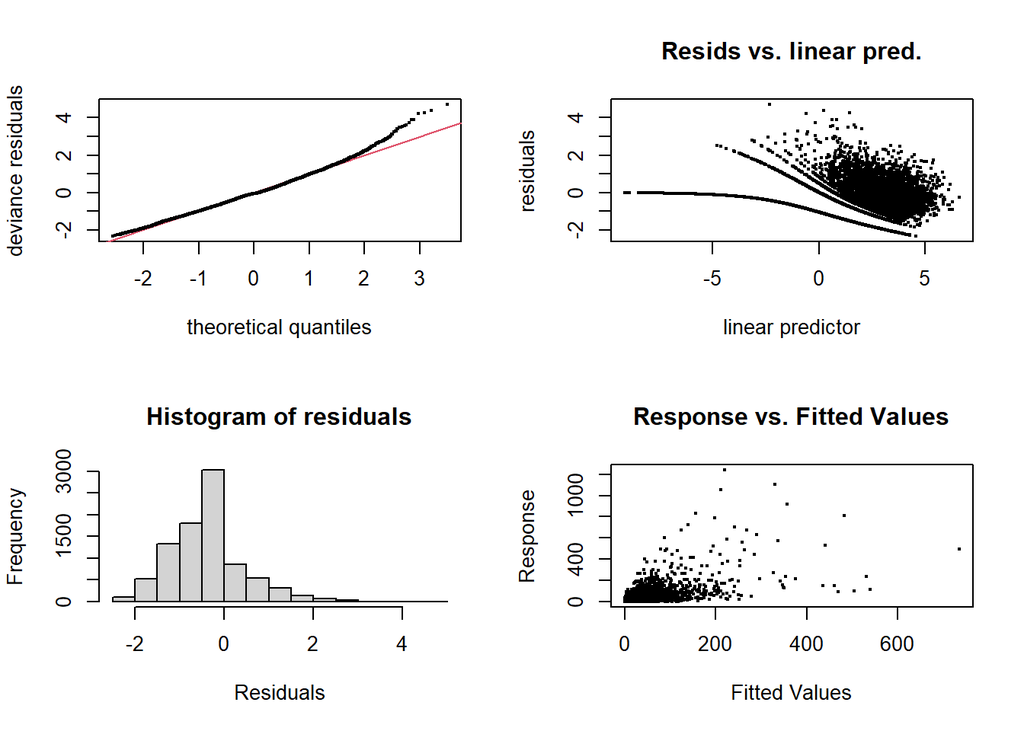

```
##
## Method: fREML   Optimizer: perf chol
## $grad
## [1] -1.090353e-07 -2.666324e-08 -1.349845e-07 -2.103533e-06 -7.487878e-07
##
## $hess
##              [,1]         [,2]        [,3]        [,4]        [,5]
## [1,] 22.536611552 -0.009745534 -0.00403550 -0.25395861 -0.06724406
## [2,] -0.009745534  1.810118978 -0.02843889 -0.09144526  0.03863398
## [3,] -0.004035500 -0.028438890  1.17703306 -0.01250733 -0.01378938
## [4,] -0.253958614 -0.091445256 -0.01250733 10.52832901 -0.43625272
## [5,] -0.067244061  0.038633976 -0.01378938 -0.43625272  2.62545127
##
## Model rank =  330 / 330
##
## Basis dimension (k) checking results. Low p-value (k-index<1) may
## indicate that k is too low, especially if edf is close to k'.
##
##                  k'    edf k-index p-value
## s(district)   49.00  47.49      NA      NA
## s(time):aet   50.00   7.07    0.82    0.50
## s(time):q     30.00   6.18    0.82    0.48
## s(time):tmax 100.00  56.75    0.82    0.47
## s(time):tmin 100.00  20.48    0.82    0.47
```

```r
par(mfrow = c(2, 2))
mgcv::gam.check(falciparum_tvcm_1, pch = 19, cex = 0.3)
```

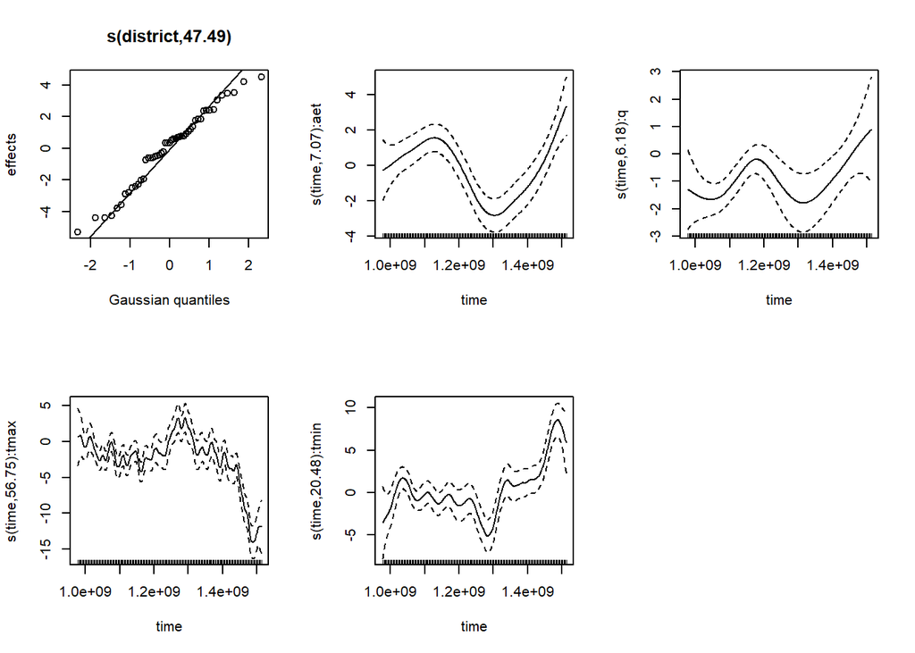

```r
mgcv::plot.gam(
  x          = falciparum_tvcm_1,
  n          = 500,
  seWithMean = TRUE,
  scale      = 0,
  pages      = 1
)
```

```r
mgcv::concurvity(falciparum_tvcm_1)
```

```
##          para s(district) s(time):aet s(time):q s(time):tmax s(time):tmin
## worst       1  1.00000000   0.9874232 0.9150569    0.9964767    0.9945815
## observed    1  0.39305121   0.9667340 0.8358246    0.9796012    0.9765262
## estimate    1  0.06681214   0.9761108 0.8495683    0.9778560    0.9816673
```

```r
mgcv::concurvity(falciparum_tvcm_1, full = FALSE)$estimate
```

```
##                   para s(district) s(time):aet s(time):q s(time):tmax
## para         1.0000000  0.02040821   0.3263991 0.2334896    0.3236243
## s(district)  1.0000000  1.00000000   0.3277819 0.2593978    0.3330388
## s(time):aet  0.9670981  0.02058471   1.0000000 0.6693921    0.9494135
## s(time):q    0.6426163  0.01516121   0.5610714 1.0000000    0.5978573
## s(time):tmax 0.9593073  0.02165244   0.9562052 0.7101258    1.0000000
## s(time):tmin 0.9693042  0.02163550   0.9528123 0.7827396    0.9497211
##              s(time):tmin
## para            0.3277106
## s(district)     0.3341381
## s(time):aet     0.9398514
## s(time):q       0.7091066
## s(time):tmax    0.9522356
## s(time):tmin    1.0000000
```

## TVCM: Model 2

Predictors: `aet`, `prcp`, `tmax`, `tmin`

### P. vivax

```r
tictoc::tic("GAM model fitting")
vivax_tvcm_2 <- mgcv::bam(
  formula =
    vivax ~
    offset(ln_pop2015) +
    s(district, bs = "re", k = 49) +
    s(time, by = aet,   bs = "tp", k = 50) +
    s(time, by = prcp,  bs = "tp", k = 30) +
    s(time, by = tmax,  bs = "tp", k = 100) +
    s(time, by = tmin,  bs = "tp", k = 100),
  family   = nb(),
  data     = train,
  method   = "fREML",
  discrete = TRUE
)
tictoc::toc()
```

```
## GAM model fitting: 2.61 sec elapsed
```

```r
cat("\nConverged?", vivax_tvcm_2$converged, "\n")
```

```
##
## Converged? TRUE
```

```r
mgcv::summary.gam(vivax_tvcm_2)
```

```
##
## Family: Negative Binomial(0.904)
## Link function: log
##
## Formula:
## vivax ~ offset(ln_pop2015) + s(district, bs = "re", k = 49) +
##     s(time, by = aet, bs = "tp", k = 50) + s(time, by = prcp,
##     bs = "tp", k = 30) + s(time, by = tmax, bs = "tp", k = 100) +
##     s(time, by = tmin, bs = "tp", k = 100)
##
## Parametric coefficients:
##             Estimate Std. Error t value Pr(>|t|)
## (Intercept)  -6.1199     0.3365  -18.19   <2e-16 ***
## ---
## Signif. codes:  0 '***' 0.001 '**' 0.01 '*' 0.05 '.' 0.1 ' ' 1
##
## Approximate significance of smooth terms:
##                 edf Ref.df       F  p-value
## s(district)  47.798 48.000 242.763  < 2e-16 ***
## s(time):aet  15.394 18.516   8.425  < 2e-16 ***
## s(time):prcp  5.175  6.192   4.096 0.000367 ***
## s(time):tmax 62.449 74.821  10.852  < 2e-16 ***
## s(time):tmin 17.821 21.597  13.483  < 2e-16 ***
## ---
## Signif. codes:  0 '***' 0.001 '**' 0.01 '*' 0.05 '.' 0.1 ' ' 1
##
## R-sq.(adj) =  0.432   Deviance explained = 69.8%
## fREML =  13039  Scale est. = 1         n = 8775
```

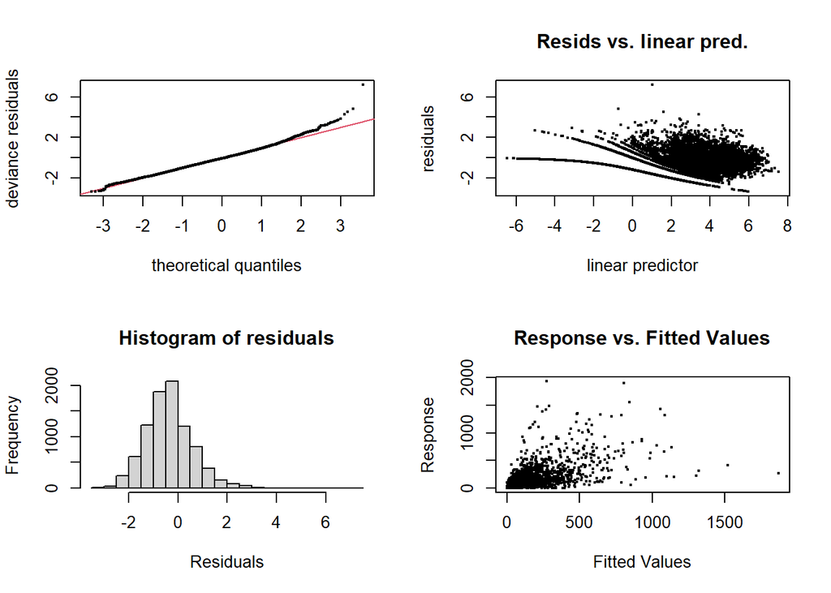

```
##
## Method: fREML   Optimizer: perf chol
## $grad
## [1] -2.593951e-08 -2.359073e-07 -9.077580e-08 -1.075109e-06 -3.332903e-07
##
## $hess
##              [,1]         [,2]         [,3]       [,4]         [,5]
## [1,] 23.263736879 -0.032349760  0.001276268 -0.3437908  0.003671283
## [2,] -0.032349760  1.516308961  0.006995752  0.6151428  0.534457755
## [3,]  0.001276268  0.006995752  1.219489596  0.1194006 -0.012733208
## [4,] -0.343790775  0.615142758  0.119400638 15.4283325  0.587411769
## [5,]  0.003671283  0.534457755 -0.012733208  0.5874118  2.845410426
##
## Model rank =  330 / 330
##
## Basis dimension (k) checking results. Low p-value (k-index<1) may
## indicate that k is too low, especially if edf is close to k'.
##
##                  k'    edf k-index p-value
## s(district)   49.00  47.80      NA      NA
## s(time):aet   50.00  15.39    0.85   0.010 **
## s(time):prcp  30.00   5.17    0.85   0.040 *
## s(time):tmax 100.00  62.45    0.85   0.020 *
## s(time):tmin 100.00  17.82    0.85   0.015 *
## ---
## Signif. codes:  0 '***' 0.001 '**' 0.01 '*' 0.05 '.' 0.1 ' ' 1
```

```r
par(mfrow = c(2, 2))
mgcv::gam.check(vivax_tvcm_2, pch = 19, cex = 0.3)
```

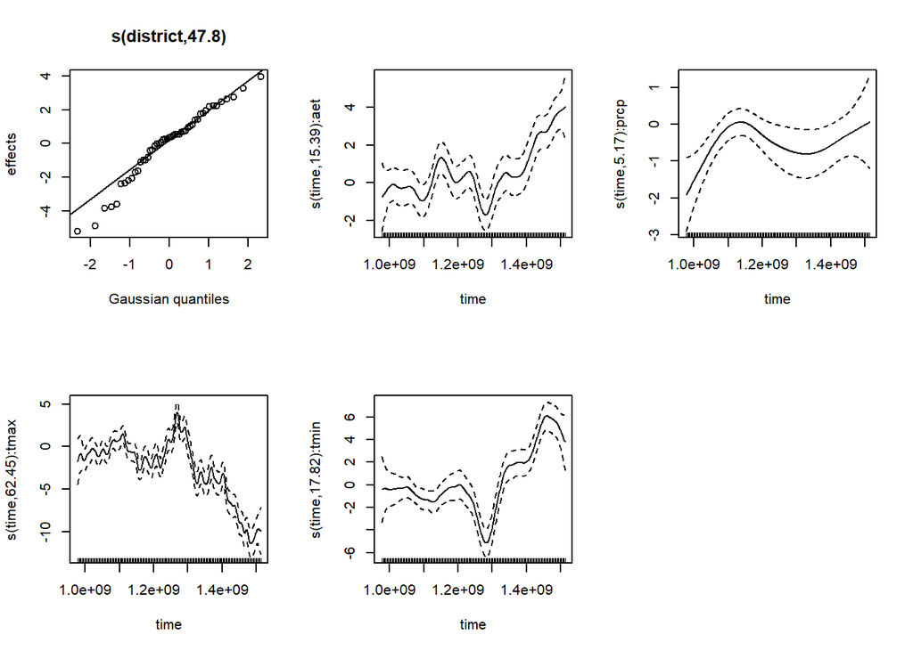

```r
mgcv::plot.gam(
  x          = vivax_tvcm_2,
  n          = 500,
  seWithMean = TRUE,
  scale      = 0,
  pages      = 1
)
```

```r
mgcv::concurvity(vivax_tvcm_2)
```

```
##          para s(district) s(time):aet s(time):prcp s(time):tmax s(time):tmin
## worst       1  1.00000000   0.9871254    0.9622885    0.9964876    0.9946484
## observed    1  0.39375195   0.9746199    0.9114866    0.9810572    0.9763248
## estimate    1  0.06675464   0.9756554    0.9135220    0.9779083    0.9817038
```

```r
mgcv::concurvity(vivax_tvcm_2, full = FALSE)$estimate
```

```
##                   para s(district) s(time):aet s(time):prcp s(time):tmax
## para         1.0000000  0.02040821   0.3264113    0.2927857    0.3234471
## s(district)  1.0000000  1.00000000   0.3277942    0.3062981    0.3328564
## s(time):aet  0.9670981  0.02058471   1.0000000    0.8042030    0.9494155
## s(time):prcp 0.8096382  0.01782830   0.7477972    1.0000000    0.7662336
## s(time):tmax 0.9593073  0.02165244   0.9562020    0.8177483    1.0000000
## s(time):tmin 0.9693042  0.02163550   0.9528087    0.8777652    0.9497172
##              s(time):tmin
## para            0.3275275
## s(district)     0.3339523
## s(time):aet     0.9398541
## s(time):prcp    0.8522166
## s(time):tmax    0.9522315
## s(time):tmin    1.0000000
```

### P. falciparum

```r
tictoc::tic("GAM model fitting")
falciparum_tvcm_2 <- mgcv::bam(
  formula =
    falciparum ~
    offset(ln_pop2015) +
    s(district, bs = "re", k = 49) +
    s(time, by = aet,   bs = "tp", k = 50) +
    s(time, by = prcp,  bs = "tp", k = 30) +
    s(time, by = tmax,  bs = "tp", k = 100) +
    s(time, by = tmin,  bs = "tp", k = 100),
  family   = nb(),
  data     = train,
  method   = "fREML",
  discrete = TRUE
)
tictoc::toc()
```

```
## GAM model fitting: 2.48 sec elapsed
```

```r
cat("\nConverged?", falciparum_tvcm_2$converged, "\n")
```

```
##
## Converged? TRUE
```

```r
mgcv::summary.gam(falciparum_tvcm_2)
```

```
##
## Family: Negative Binomial(0.528)
## Link function: log
##
## Formula:
## falciparum ~ offset(ln_pop2015) + s(district, bs = "re", k = 49) +
##     s(time, by = aet, bs = "tp", k = 50) + s(time, by = prcp,
##     bs = "tp", k = 30) + s(time, by = tmax, bs = "tp", k = 100) +
##     s(time, by = tmin, bs = "tp", k = 100)
##
## Parametric coefficients:
##             Estimate Std. Error t value Pr(>|t|)
## (Intercept)  -7.3654     0.4079  -18.05   <2e-16 ***
## ---
## Signif. codes:  0 '***' 0.001 '**' 0.01 '*' 0.05 '.' 0.1 ' ' 1
##
## Approximate significance of smooth terms:
##                 edf Ref.df       F p-value
## s(district)  47.491 49.000 148.573  <2e-16 ***
## s(time):aet   6.908  8.256   9.405  <2e-16 ***
## s(time):prcp  6.008  7.217   7.014  <2e-16 ***
## s(time):tmax 56.999 68.770   5.660  <2e-16 ***
## s(time):tmin 20.556 24.943   6.714  <2e-16 ***
## ---
## Signif. codes:  0 '***' 0.001 '**' 0.01 '*' 0.05 '.' 0.1 ' ' 1
##
## R-sq.(adj) =  0.404   Deviance explained = 66.3%
## fREML =  12123  Scale est. = 1         n = 8775
```

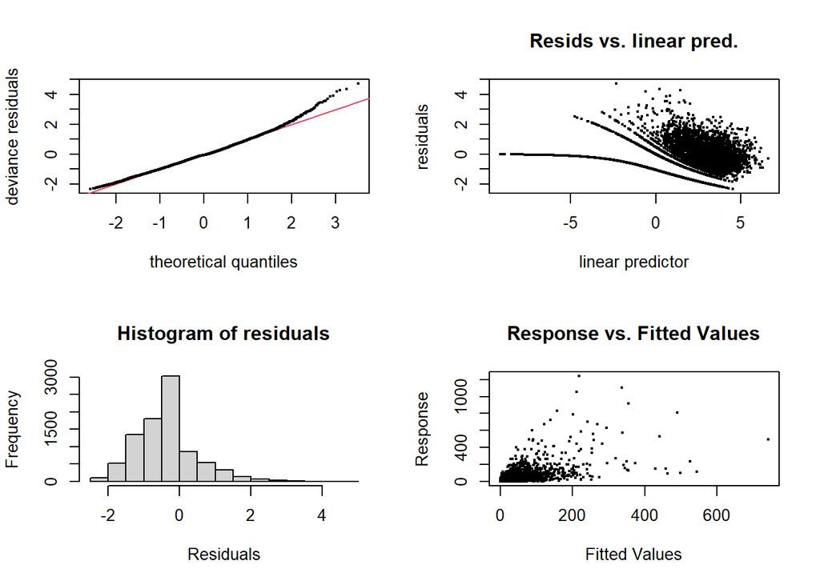

```
##
## Method: fREML   Optimizer: perf chol
## $grad
## [1] -2.319035e-08 -8.312759e-10 -2.252941e-08 -2.425768e-07 -2.116946e-08
##
## $hess
##              [,1]         [,2]         [,3]        [,4]        [,5]
## [1,] 22.533958165 -0.009881531 -0.005072025 -0.24899443 -0.06683571
## [2,] -0.009881531  1.755946195  0.022215000 -0.10909561  0.03795902
## [3,] -0.005072025  0.022215000  1.084589360 -0.04062459 -0.02380914
## [4,] -0.248994430 -0.109095613 -0.040624587 10.49762165 -0.43093728
## [5,] -0.066835714  0.037959015 -0.023809144 -0.43093728  2.62650035
##
## Model rank =  330 / 330
##
## Basis dimension (k) checking results. Low p-value (k-index<1) may
## indicate that k is too low, especially if edf is close to k'.
##
##                  k'    edf k-index p-value
## s(district)   49.00  47.49      NA      NA
## s(time):aet   50.00   6.91    0.84    0.67
## s(time):prcp  30.00   6.01    0.84    0.63
## s(time):tmax 100.00  57.00    0.84    0.69
## s(time):tmin 100.00  20.56    0.84    0.58
```

```r
par(mfrow = c(2, 2))
mgcv::gam.check(falciparum_tvcm_2, pch = 19, cex = 0.3)
```

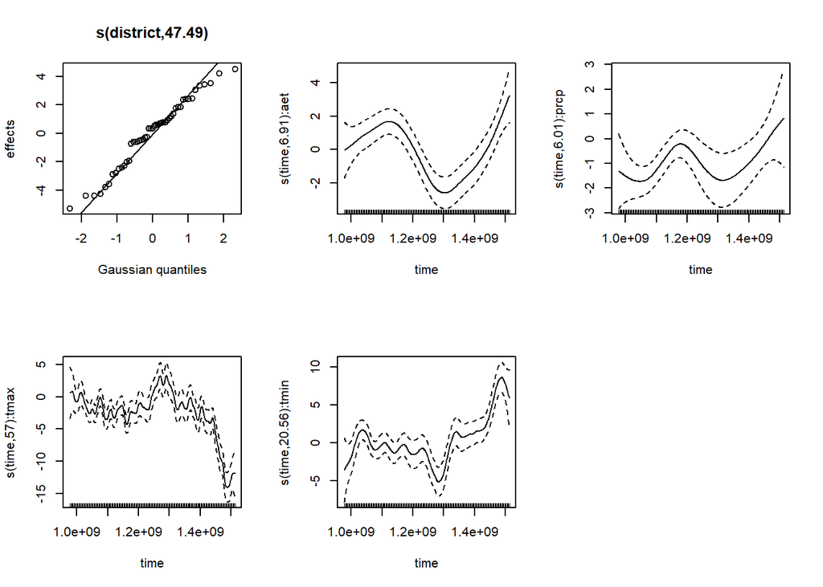

```r
mgcv::plot.gam(
  x          = falciparum_tvcm_2,
  n          = 500,
  seWithMean = TRUE,
  scale      = 0,
  pages      = 1
)
```

```r
mgcv::concurvity(falciparum_tvcm_2)
```

```
##          para s(district) s(time):aet s(time):prcp s(time):tmax s(time):tmin
## worst       1  1.00000000   0.9871254    0.9622885    0.9964876    0.9946484
## observed    1  0.39253636   0.9689363    0.9050412    0.9796362    0.9765463
## estimate    1  0.06675464   0.9756624    0.9135317    0.9779348    0.9817227
```

```r
mgcv::concurvity(falciparum_tvcm_2, full = FALSE)$estimate
```

```
##                   para s(district) s(time):aet s(time):prcp s(time):tmax
## para         1.0000000  0.02040821   0.3273656    0.2935909    0.3245431
## s(district)  1.0000000  1.00000000   0.3287519    0.3071594    0.3339902
## s(time):aet  0.9670981  0.02058471   1.0000000    0.8041014    0.9493928
## s(time):prcp 0.8096382  0.01782830   0.7477882    1.0000000    0.7662086
## s(time):tmax 0.9593073  0.02165244   0.9561881    0.8176562    1.0000000
## s(time):tmin 0.9693042  0.02163550   0.9527952    0.8777149    0.9497090
##              s(time):tmin
## para            0.3286482
## s(district)     0.3350910
## s(time):aet     0.9398311
## s(time):prcp    0.8522057
## s(time):tmax    0.9522241
## s(time):tmin    1.0000000
```

## TVCM: Model 3

### P. vivax

Predictors: `aet`, `q`, `tmin`

```r
tictoc::tic("GAM model fitting")
vivax_tvcm_3 <- mgcv::bam(
  formula =
    vivax ~
    offset(ln_pop2015) +
    s(district, bs = "re", k = 49) +
    s(time, by = aet,  bs = "tp", k = 50) +
    s(time, by = q,    bs = "tp", k = 30) +
    s(time, by = tmin, bs = "tp", k = 100),
  family   = nb(),
  data     = train,
  method   = "fREML",
  discrete = TRUE
)
tictoc::toc()
```

```
## GAM model fitting: 1.9 sec elapsed
```

```r
cat("\nConverged?", vivax_tvcm_3$converged, "\n")
```

```
##
## Converged? TRUE
```

```r
mgcv::summary.gam(vivax_tvcm_3)
```

```
##
## Family: Negative Binomial(0.836)
## Link function: log
##
## Formula:
## vivax ~ offset(ln_pop2015) + s(district, bs = "re", k = 49) +
##     s(time, by = aet, bs = "tp", k = 50) + s(time, by = q, bs = "tp",
##     k = 30) + s(time, by = tmin, bs = "tp", k = 100)
##
## Parametric coefficients:
##             Estimate Std. Error t value Pr(>|t|)
## (Intercept)   -6.702      0.339  -19.77   <2e-16 ***
## ---
## Signif. codes:  0 '***' 0.001 '**' 0.01 '*' 0.05 '.' 0.1 ' ' 1
##
## Approximate significance of smooth terms:
##                 edf Ref.df       F  p-value
## s(district)  47.819 48.000 266.257  < 2e-16 ***
## s(time):aet   5.317  6.289   3.797 0.000709 ***
## s(time):q     4.896  5.857   4.021 0.000772 ***
## s(time):tmin 66.339 79.048   8.919  < 2e-16 ***
## ---
## Signif. codes:  0 '***' 0.001 '**' 0.01 '*' 0.05 '.' 0.1 ' ' 1
##
## R-sq.(adj) =  0.485   Deviance explained = 67.5%
## fREML =  13023  Scale est. = 1         n = 8775
```

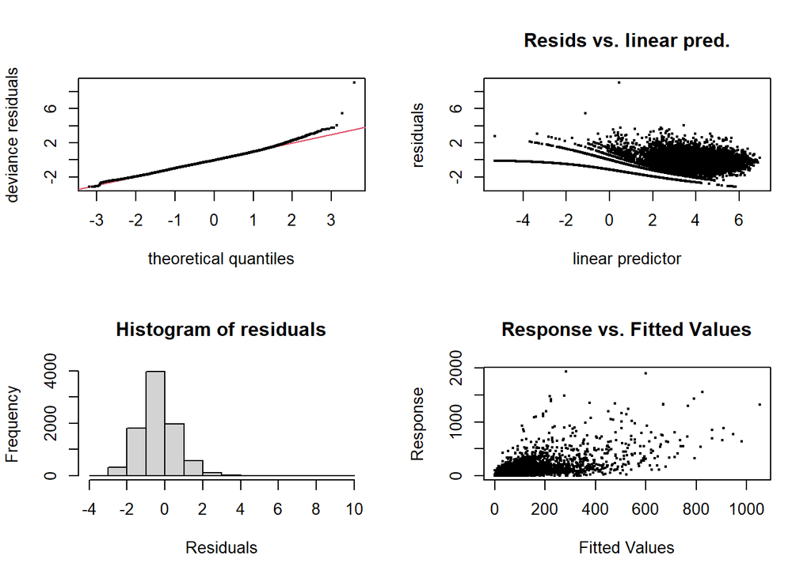

```
##
## Method: fREML   Optimizer: perf chol
## $grad
## [1] 1.823381e-09 9.892717e-09 4.034584e-09 9.311599e-08
##
## $hess
##              [,1]         [,2]         [,3]        [,4]
## [1,] 23.422244567 -0.002544174 -0.003000642 -0.09414526
## [2,] -0.002544174  1.477410558 -0.044995693 -0.08965296
## [3,] -0.003000642 -0.044995693  0.856747486  0.15257563
## [4,] -0.094145258 -0.089652958  0.152575630 21.07564348
##
## Model rank =  230 / 230
##
## Basis dimension (k) checking results. Low p-value (k-index<1) may
## indicate that k is too low, especially if edf is close to k'.
##
##                  k'    edf k-index p-value
## s(district)   49.00  47.82      NA      NA
## s(time):aet   50.00   5.32    0.87    0.42
## s(time):q     30.00   4.90    0.87    0.44
## s(time):tmin 100.00  66.34    0.87    0.40
```

```r
par(mfrow = c(2, 2))
mgcv::gam.check(vivax_tvcm_3, pch = 19, cex = 0.3)
```

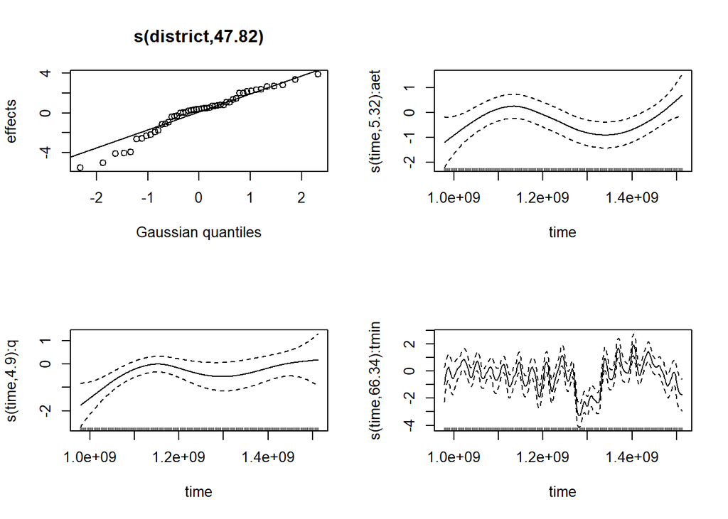

```r
mgcv::plot.gam(
  x          = vivax_tvcm_3,
  n          = 500,
  seWithMean = TRUE,
  scale      = 0,
  pages      = 1
)
```

```r
mgcv::concurvity(vivax_tvcm_3)
```

```
##          para s(district) s(time):aet s(time):q s(time):tmin
## worst       1  1.00000000   0.9819737 0.9078071    0.9914077
## observed    1  0.14424628   0.9594925 0.8076273    0.9342511
## estimate    1  0.04678371   0.9650774 0.8296325    0.9687334
```

```r
mgcv::concurvity(vivax_tvcm_3, full = FALSE)$estimate
```

```
##                   para s(district) s(time):aet s(time):q s(time):tmin
## para         1.0000000  0.02040821   0.3312669 0.2376283    0.3325233
## s(district)  1.0000000  1.00000000   0.3326673 0.2641126    0.3390295
## s(time):aet  0.9670981  0.02058471   1.0000000 0.6687134    0.9397601
## s(time):q    0.6426163  0.01516121   0.5610280 1.0000000    0.7091408
## s(time):tmin 0.9693042  0.02163550   0.9527365 0.7823282    1.0000000
```

### P. falciparum

Predictors: `aet`, `q`, `tmin`

```r
tictoc::tic("GAM model fitting")
falciparum_tvcm_3 <- mgcv::bam(
  formula =
    falciparum ~
    offset(ln_pop2015) +
    s(district, bs = "re", k = 49) +
    s(time, by = aet,  bs = "tp", k = 50) +
    s(time, by = q,    bs = "tp", k = 30) +
    s(time, by = tmin, bs = "tp", k = 100),
  family   = nb(),
  data     = train,
  method   = "fREML",
  discrete = TRUE
)
tictoc::toc()
```

```
## GAM model fitting: 2.03 sec elapsed
```

```r
cat("\nConverged?", falciparum_tvcm_3$converged, "\n")
```

```
##
## Converged? TRUE
```

```r
mgcv::summary.gam(falciparum_tvcm_3)
```

```
##
## Family: Negative Binomial(0.502)
## Link function: log
##
## Formula:
## falciparum ~ offset(ln_pop2015) + s(district, bs = "re", k = 49) +
##     s(time, by = aet, bs = "tp", k = 50) + s(time, by = q, bs = "tp",
##     k = 30) + s(time, by = tmin, bs = "tp", k = 100)
##
## Parametric coefficients:
##             Estimate Std. Error t value Pr(>|t|)
## (Intercept)  -7.9912     0.4039  -19.79   <2e-16 ***
## ---
## Signif. codes:  0 '***' 0.001 '**' 0.01 '*' 0.05 '.' 0.1 ' ' 1
##
## Approximate significance of smooth terms:
##                 edf Ref.df       F p-value
## s(district)  47.540 48.000 163.513  <2e-16 ***
## s(time):aet   5.591  6.597   9.609  <2e-16 ***
## s(time):q     6.692  8.051   6.396  <2e-16 ***
## s(time):tmin 54.882 66.796   5.526  <2e-16 ***
## ---
## Signif. codes:  0 '***' 0.001 '**' 0.01 '*' 0.05 '.' 0.1 ' ' 1
##
## R-sq.(adj) =  0.368   Deviance explained = 64.6%
## fREML =  12096  Scale est. = 1         n = 8775
```

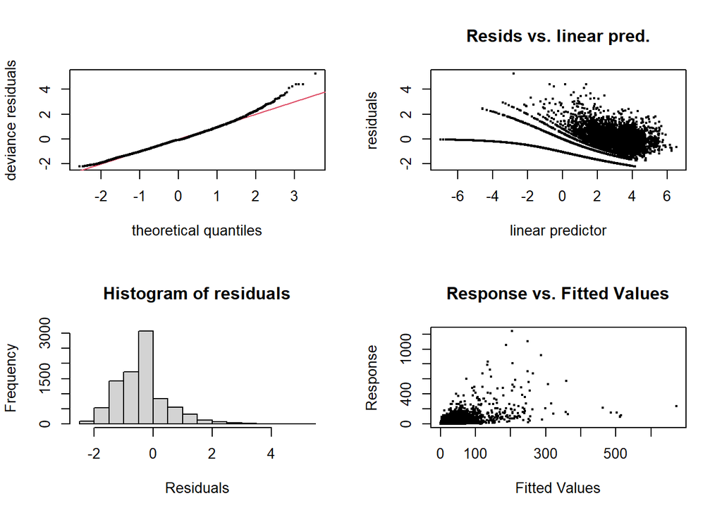

```
##
## Method: fREML   Optimizer: perf chol
## $grad
## [1] 1.333928e-08 3.013287e-08 4.099244e-08 4.016416e-07
##
## $hess
##              [,1]         [,2]         [,3]        [,4]
## [1,] 22.804175416 -0.006929443 -0.001719331 -0.07850489
## [2,] -0.006929443  1.123248279 -0.032517511 -0.07518629
## [3,] -0.001719331 -0.032517511  1.288398914 -0.13003848
## [4,] -0.078504894 -0.075186292 -0.130038475 12.01231517
##
## Model rank =  230 / 230
##
## Basis dimension (k) checking results. Low p-value (k-index<1) may
## indicate that k is too low, especially if edf is close to k'.
##
##                  k'    edf k-index p-value
## s(district)   49.00  47.54      NA      NA
## s(time):aet   50.00   5.59    0.81    0.14
## s(time):q     30.00   6.69    0.81    0.12
## s(time):tmin 100.00  54.88    0.81    0.12
```

```r
par(mfrow = c(2, 2))
mgcv::gam.check(falciparum_tvcm_3, pch = 19, cex = 0.3)
```

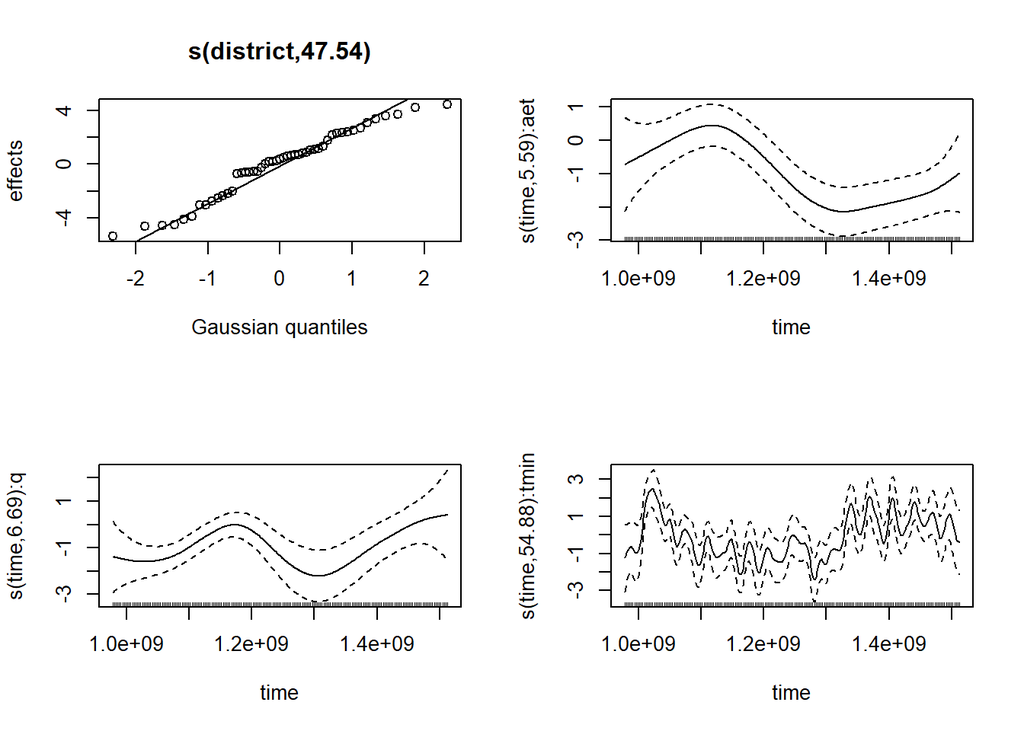

```r
mgcv::plot.gam(
  x          = falciparum_tvcm_3,
  n          = 500,
  seWithMean = TRUE,
  scale      = 0,
  pages      = 1
)
```

```r
mgcv::concurvity(falciparum_tvcm_3)
```

```
##          para s(district) s(time):aet s(time):q s(time):tmin
## worst       1  1.00000000   0.9819737 0.9078071    0.9914077
## observed    1  0.10636936   0.9657385 0.8204711    0.9391819
## estimate    1  0.04678371   0.9650860 0.8297041    0.9687421
```

```r
mgcv::concurvity(falciparum_tvcm_3, full = FALSE)$estimate
```

```
##                   para s(district) s(time):aet s(time):q s(time):tmin
## para         1.0000000  0.02040821   0.3313549 0.2376185    0.3327641
## s(district)  1.0000000  1.00000000   0.3327552 0.2640822    0.3392741
## s(time):aet  0.9670981  0.02058471   1.0000000 0.6688507    0.9397626
## s(time):q    0.6426163  0.01516121   0.5610952 1.0000000    0.7091689
## s(time):tmin 0.9693042  0.02163550   0.9527467 0.7824230    1.0000000
```

## TVCM: Model 4

Predictors: `aet`, `q`, `tmax`

### P. vivax

```r
tictoc::tic("GAM model fitting")
vivax_tvcm_4 <- mgcv::bam(
  formula =
    vivax ~
    offset(ln_pop2015) +
    s(district, bs = "re", k = 49) +
    s(time, by = aet,  bs = "tp", k = 50) +
    s(time, by = q,    bs = "tp", k = 30) +
    s(time, by = tmax, bs = "tp", k = 100),
  family   = nb(),
  data     = train,
  method   = "fREML",
  discrete = TRUE
)
tictoc::toc()
```

```
## GAM model fitting: 1.74 sec elapsed
```

```r
cat("\nConverged?", vivax_tvcm_4$converged, "\n")
```

```
##
## Converged? TRUE
```

```r
mgcv::summary.gam(vivax_tvcm_4)
```

```
##
## Family: Negative Binomial(0.868)
## Link function: log
##
## Formula:
## vivax ~ offset(ln_pop2015) + s(district, bs = "re", k = 49) +
##     s(time, by = aet, bs = "tp", k = 50) + s(time, by = q, bs = "tp",
##     k = 30) + s(time, by = tmax, bs = "tp", k = 100)
##
## Parametric coefficients:
##             Estimate Std. Error t value Pr(>|t|)
## (Intercept)    -6.15       0.33  -18.64   <2e-16 ***
## ---
## Signif. codes:  0 '***' 0.001 '**' 0.01 '*' 0.05 '.' 0.1 ' ' 1
##
## Approximate significance of smooth terms:
##                 edf Ref.df       F p-value
## s(district)  47.802 49.000 233.927  <2e-16 ***
## s(time):aet  19.548 23.328  13.919  <2e-16 ***
## s(time):q     6.235  7.481   9.765  <2e-16 ***
## s(time):tmax 61.213 73.846   8.128  <2e-16 ***
## ---
## Signif. codes:  0 '***' 0.001 '**' 0.01 '*' 0.05 '.' 0.1 ' ' 1
##
## R-sq.(adj) =  0.489   Deviance explained = 68.7%
## fREML =  13025  Scale est. = 1         n = 8775
```

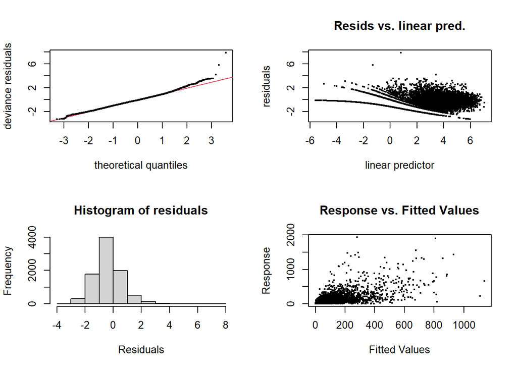

```
##
## Method: fREML   Optimizer: perf chol
## $grad
## [1] -2.415828e-08 -2.611385e-07 -2.259646e-08 -6.952679e-07
##
## $hess
##             [,1]        [,2]        [,3]        [,4]
## [1,] 23.31430645 -0.02027829 -0.01316589 -0.22608072
## [2,] -0.02027829  2.65783779  0.09773539  1.04680866
## [3,] -0.01316589  0.09773539  1.55393951  0.07816724
## [4,] -0.22608072  1.04680866  0.07816724 14.73506919
##
## Model rank =  230 / 230
##
## Basis dimension (k) checking results. Low p-value (k-index<1) may
## indicate that k is too low, especially if edf is close to k'.
##
##                  k'    edf k-index p-value
## s(district)   49.00  47.80      NA      NA
## s(time):aet   50.00  19.55    0.87    0.28
## s(time):q     30.00   6.24    0.87    0.24
## s(time):tmax 100.00  61.21    0.87    0.28
```

```r
par(mfrow = c(2, 2))
mgcv::gam.check(vivax_tvcm_4, pch = 19, cex = 0.3)
```

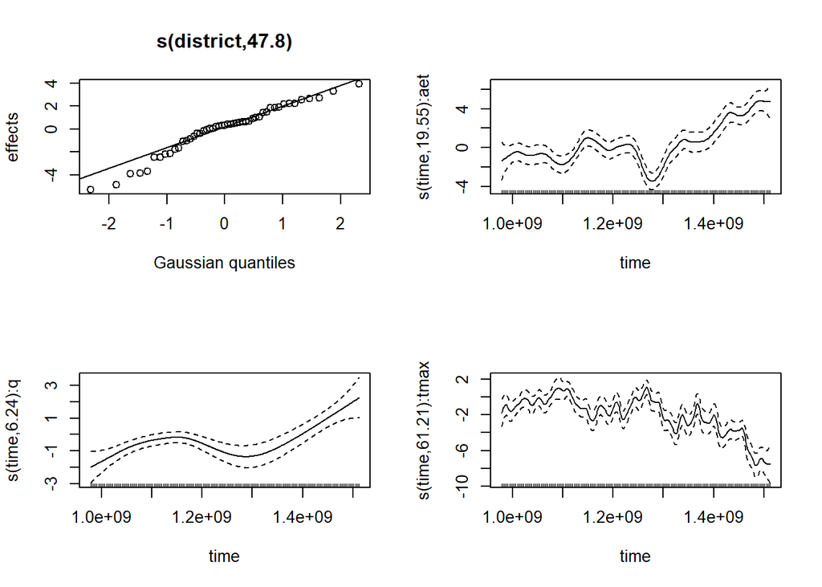

```r
mgcv::plot.gam(
  x          = vivax_tvcm_4,
  n          = 500,
  seWithMean = TRUE,
  scale      = 0,
  pages      = 1
)
```

```r
mgcv::concurvity(vivax_tvcm_4)
```

```
##          para s(district) s(time):aet s(time):q s(time):tmax
## worst       1  1.00000000   0.9842259 0.8850141    0.9943495
## observed    1  0.29019686   0.9597187 0.7732234    0.9762043
## estimate    1  0.04911348   0.9672177 0.7889128    0.9663542
```

```r
mgcv::concurvity(vivax_tvcm_4, full = FALSE)$estimate
```

```
##                   para s(district) s(time):aet s(time):q s(time):tmax
## para         1.0000000  0.02040821   0.3305144 0.2369671    0.3276175
## s(district)  1.0000000  1.00000000   0.3319119 0.2633556    0.3371706
## s(time):aet  0.9670981  0.02058471   1.0000000 0.6688439    0.9493343
## s(time):q    0.6426163  0.01516121   0.5610375 1.0000000    0.5978156
## s(time):tmax 0.9593073  0.02165244   0.9561399 0.7095623    1.0000000
```

### P. falciparum

```r
tictoc::tic("GAM model fitting")
falciparum_tvcm_4 <- mgcv::bam(
  formula =
    falciparum ~
    offset(ln_pop2015) +
    s(district, bs = "re", k = 49) +
    s(time, by = aet,  bs = "tp", k = 50) +
    s(time, by = q,    bs = "tp", k = 30) +
    s(time, by = tmax, bs = "tp", k = 100),
  family   = nb(),
  data     = train,
  method   = "fREML",
  discrete = TRUE
)
tictoc::toc()
```

```
## GAM model fitting: 1.96 sec elapsed
```

```r
cat("\nConverged?", falciparum_tvcm_4$converged, "\n")
```

```
##
## Converged? TRUE
```

```r
mgcv::summary.gam(falciparum_tvcm_4)
```

```
##
## Family: Negative Binomial(0.509)
## Link function: log
##
## Formula:
## falciparum ~ offset(ln_pop2015) + s(district, bs = "re", k = 49) +
##     s(time, by = aet, bs = "tp", k = 50) + s(time, by = q, bs = "tp",
##     k = 30) + s(time, by = tmax, bs = "tp", k = 100)
##
## Parametric coefficients:
##             Estimate Std. Error t value Pr(>|t|)
## (Intercept)  -7.3469     0.3931  -18.69   <2e-16 ***
## ---
## Signif. codes:  0 '***' 0.001 '**' 0.01 '*' 0.05 '.' 0.1 ' ' 1
##
## Approximate significance of smooth terms:
##                 edf Ref.df       F p-value
## s(district)  47.497 48.000 150.049  <2e-16 ***
## s(time):aet   8.343 10.042  12.013  <2e-16 ***
## s(time):q     8.003  9.631  10.400  <2e-16 ***
## s(time):tmax 53.171 64.948   5.862  <2e-16 ***
## ---
## Signif. codes:  0 '***' 0.001 '**' 0.01 '*' 0.05 '.' 0.1 ' ' 1
##
## R-sq.(adj) =  0.337   Deviance explained = 65.2%
## fREML =  12086  Scale est. = 1         n = 8775
```

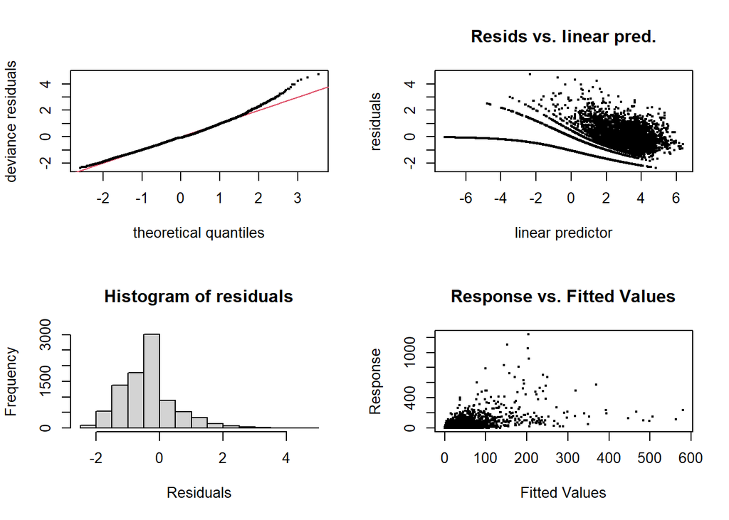

```
##
## Method: fREML   Optimizer: perf chol
## $grad
## [1] 2.170223e-08 3.371836e-08 4.125859e-08 4.125141e-07
##
## $hess
##              [,1]        [,2]         [,3]        [,4]
## [1,] 22.603830349  0.01544913 -0.004200346 -0.15857678
## [2,]  0.015449132  1.33588103  0.081277904 -0.11769053
## [3,] -0.004200346  0.08127790  1.389693095  0.04173653
## [4,] -0.158576775 -0.11769053  0.041736533  9.43365091
##
## Model rank =  230 / 230
##
## Basis dimension (k) checking results. Low p-value (k-index<1) may
## indicate that k is too low, especially if edf is close to k'.
##
##                  k'    edf k-index p-value
## s(district)   49.00  47.50      NA      NA
## s(time):aet   50.00   8.34    0.83    0.37
## s(time):q     30.00   8.00    0.83    0.43
## s(time):tmax 100.00  53.17    0.83    0.46
```

```r
par(mfrow = c(2, 2))
mgcv::gam.check(falciparum_tvcm_4, pch = 19, cex = 0.3)
```

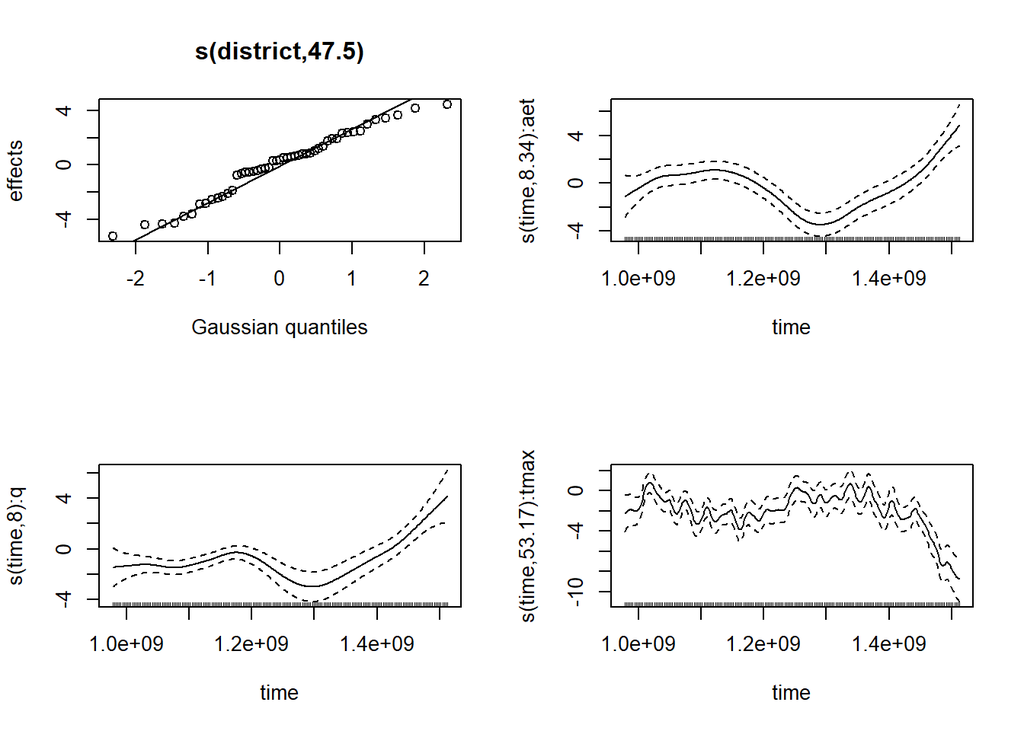

```r
mgcv::plot.gam(
  x          = falciparum_tvcm_4,
  n          = 500,
  seWithMean = TRUE,
  scale      = 0,
  pages      = 1
)
```

```r
mgcv::concurvity(falciparum_tvcm_4)
```

```
##          para s(district) s(time):aet s(time):q s(time):tmax
## worst       1  1.00000000   0.9842259 0.8850141    0.9943495
## observed    1  0.30750802   0.9543524 0.7865456    0.9770180
## estimate    1  0.04911348   0.9672224 0.7889631    0.9663641
```

```r
mgcv::concurvity(falciparum_tvcm_4, full = FALSE)$estimate
```

```
##                   para s(district) s(time):aet s(time):q s(time):tmax
## para         1.0000000  0.02040821   0.3307211 0.2371555    0.3278400
## s(district)  1.0000000  1.00000000   0.3321192 0.2635617    0.3373997
## s(time):aet  0.9670981  0.02058471   1.0000000 0.6688631    0.9493339
## s(time):q    0.6426163  0.01516121   0.5610596 1.0000000    0.5978315
## s(time):tmax 0.9593073  0.02165244   0.9561399 0.7095879    1.0000000
```

## TVCM: Model 5

Predictors: `aet`, `prcp`, `tmin`

### P. vivax

```r
tictoc::tic("GAM model fitting")
vivax_tvcm_5 <- mgcv::bam(
  formula =
    vivax ~
    offset(ln_pop2015) +
    s(district, bs = "re", k = 49) +
    s(time, by = aet,  bs = "tp", k = 50) +
    s(time, by = prcp, bs = "tp", k = 30) +
    s(time, by = tmin, bs = "tp", k = 100),
  family   = nb(),
  data     = train,
  method   = "fREML",
  discrete = TRUE
)
tictoc::toc()
```

```
## GAM model fitting: 1.93 sec elapsed
```

```r
cat("\nConverged?", vivax_tvcm_5$converged, "\n")
```

```
##
## Converged? TRUE
```

```r
mgcv::summary.gam(vivax_tvcm_5)
```

```
##
## Family: Negative Binomial(0.835)
## Link function: log
##
## Formula:
## vivax ~ offset(ln_pop2015) + s(district, bs = "re", k = 49) +
##     s(time, by = aet, bs = "tp", k = 50) + s(time, by = prcp,
##     bs = "tp", k = 30) + s(time, by = tmin, bs = "tp", k = 100)
##
## Parametric coefficients:
##             Estimate Std. Error t value Pr(>|t|)
## (Intercept)  -6.6979     0.3393  -19.74   <2e-16 ***
## ---
## Signif. codes:  0 '***' 0.001 '**' 0.01 '*' 0.05 '.' 0.1 ' ' 1
##
## Approximate significance of smooth terms:
##                 edf Ref.df       F p-value
## s(district)  47.819 49.000 260.798 < 2e-16 ***
## s(time):aet   5.132  6.059   3.249 0.00326 **
## s(time):prcp  4.828  5.776   3.657 0.00133 **
## s(time):tmin 66.330 79.037   8.997 < 2e-16 ***
## ---
## Signif. codes:  0 '***' 0.001 '**' 0.01 '*' 0.05 '.' 0.1 ' ' 1
##
## R-sq.(adj) =  0.486   Deviance explained = 67.5%
## fREML =  13023  Scale est. = 1         n = 8775
```

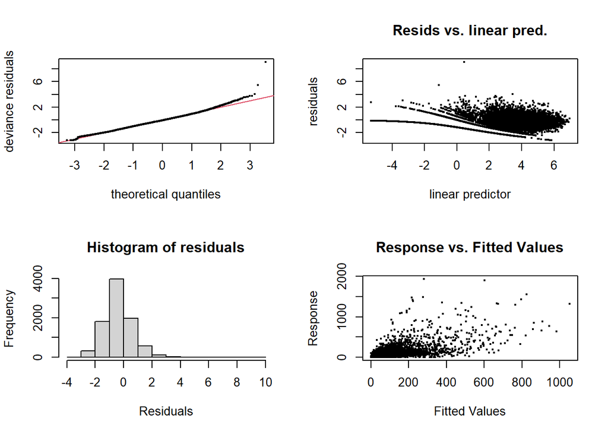

```
##
## Method: fREML   Optimizer: perf chol
## $grad
## [1] 7.288836e-09 2.008556e-08 1.603967e-08 1.716886e-07
##
## $hess
##              [,1]         [,2]         [,3]        [,4]
## [1,] 23.422111077 -0.002082422 -0.004416042 -0.09391558
## [2,] -0.002082422  1.360016753  0.007057921 -0.11686329
## [3,] -0.004416042  0.007057921  0.876936915  0.16532154
## [4,] -0.093915576 -0.116863287  0.165321535 21.12272663
##
## Model rank =  230 / 230
##
## Basis dimension (k) checking results. Low p-value (k-index<1) may
## indicate that k is too low, especially if edf is close to k'.
##
##                  k'    edf k-index p-value
## s(district)   49.00  47.82      NA      NA
## s(time):aet   50.00   5.13    0.88    0.73
## s(time):prcp  30.00   4.83    0.88    0.66
## s(time):tmin 100.00  66.33    0.88    0.66
```

```r
par(mfrow = c(2, 2))
mgcv::gam.check(vivax_tvcm_5, pch = 19, cex = 0.3)
```

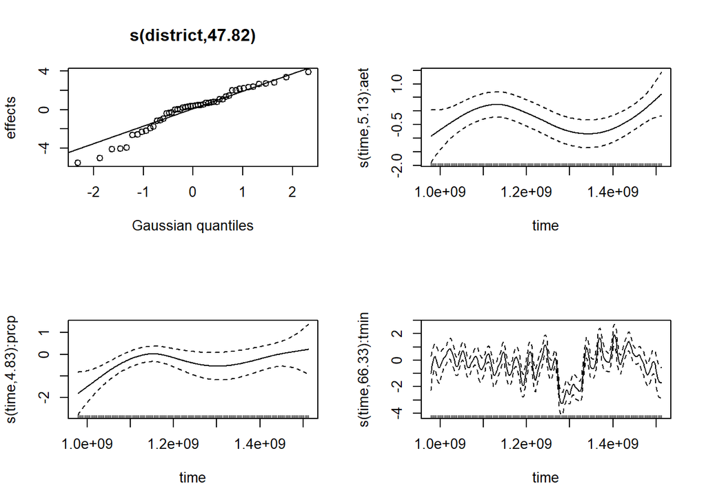

```r
mgcv::plot.gam(
  x          = vivax_tvcm_5,
  n          = 500,
  seWithMean = TRUE,
  scale      = 0,
  pages      = 1
)
```

```r
mgcv::concurvity(vivax_tvcm_5)
```

```
##          para s(district) s(time):aet s(time):prcp s(time):tmin
## worst       1   1.0000000   0.9812346    0.9594706    0.9914611
## observed    1   0.1440359   0.9607836    0.8850413    0.9353498
## estimate    1   0.0466636   0.9633820    0.9011379    0.9692008
```

```r
mgcv::concurvity(vivax_tvcm_5, full = FALSE)$estimate
```

```
##                   para s(district) s(time):aet s(time):prcp s(time):tmin
## para         1.0000000  0.02040821   0.3301088    0.2964184    0.3313685
## s(district)  1.0000000  1.00000000   0.3315049    0.3101524    0.3378559
## s(time):aet  0.9670981  0.02058471   1.0000000    0.8038335    0.9397815
## s(time):prcp 0.8096382  0.01782830   0.7477477    1.0000000    0.8521732
## s(time):tmin 0.9693042  0.02163550   0.9527565    0.8775596    1.0000000
```

### P. falciparum

```r
tictoc::tic("GAM model fitting")
falciparum_tvcm_5 <- mgcv::bam(
  formula =
    falciparum ~
    offset(ln_pop2015) +
    s(district, bs = "re", k = 49) +
    s(time, by = aet,  bs = "tp", k = 50) +
    s(time, by = prcp, bs = "tp", k = 30) +
    s(time, by = tmin, bs = "tp", k = 100),
  family   = nb(),
  data     = train,
  method   = "fREML",
  discrete = TRUE
)
tictoc::toc()
```

```
## GAM model fitting: 1.91 sec elapsed
```

```r
cat("\nConverged?", falciparum_tvcm_5$converged, "\n")
```

```
##
## Converged? TRUE
```

```r
mgcv::summary.gam(falciparum_tvcm_5)
```

```
##
## Family: Negative Binomial(0.501)
## Link function: log
##
## Formula:
## falciparum ~ offset(ln_pop2015) + s(district, bs = "re", k = 49) +
##     s(time, by = aet, bs = "tp", k = 50) + s(time, by = prcp,
##     bs = "tp", k = 30) + s(time, by = tmin, bs = "tp", k = 100)
##
## Parametric coefficients:
##             Estimate Std. Error t value Pr(>|t|)
## (Intercept)  -7.9686     0.4043  -19.71   <2e-16 ***
## ---
## Signif. codes:  0 '***' 0.001 '**' 0.01 '*' 0.05 '.' 0.1 ' ' 1
##
## Approximate significance of smooth terms:
##                 edf Ref.df       F  p-value
## s(district)  47.539 48.000 163.372  < 2e-16 ***
## s(time):aet   5.261  6.189   9.510  < 2e-16 ***
## s(time):prcp  6.409  7.714   6.118 4.22e-07 ***
## s(time):tmin 54.896 66.810   5.520  < 2e-16 ***
## ---
## Signif. codes:  0 '***' 0.001 '**' 0.01 '*' 0.05 '.' 0.1 ' ' 1
##
## R-sq.(adj) =   0.37   Deviance explained = 64.6%
## fREML =  12095  Scale est. = 1         n = 8775
```

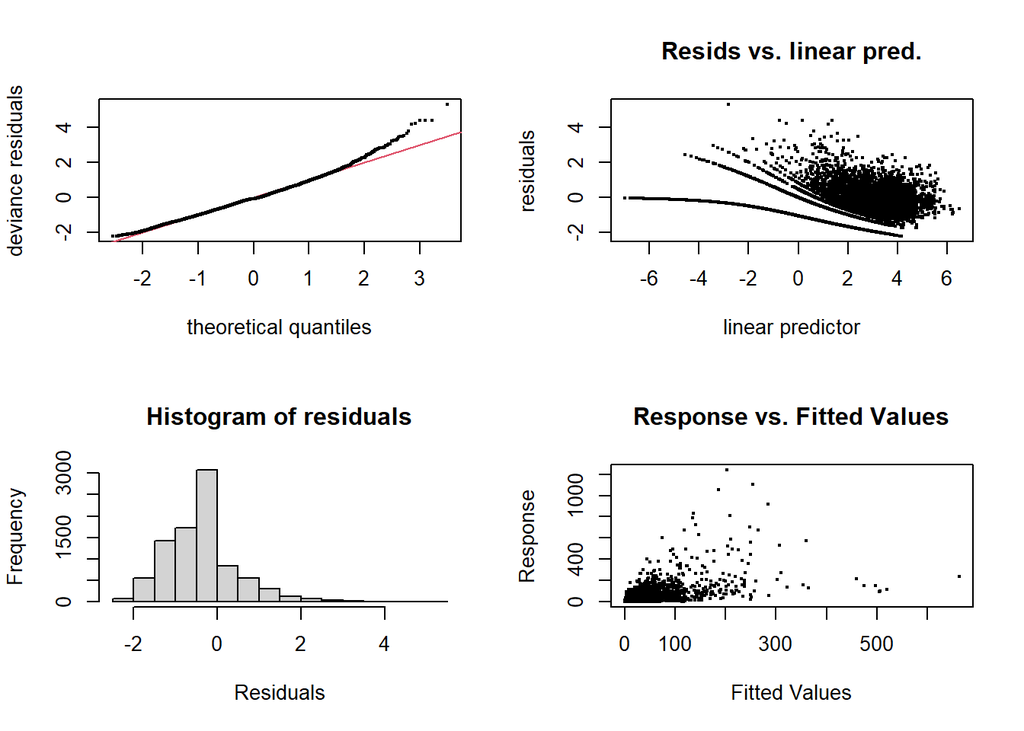

```
##
## Method: fREML   Optimizer: perf chol
## $grad
## [1] 1.129196e-08 4.657527e-09 7.896044e-10 5.284582e-08
##
## $hess
##              [,1]         [,2]         [,3]        [,4]
## [1,] 22.803285771 -0.007382548 -0.002288801 -0.07711494
## [2,] -0.007382548  1.013056054  0.025588724 -0.11786905
## [3,] -0.002288801  0.025588724  1.162724776 -0.11275313
## [4,] -0.077114944 -0.117869050 -0.112753129 12.01059650
##
## Model rank =  230 / 230
##
## Basis dimension (k) checking results. Low p-value (k-index<1) may
## indicate that k is too low, especially if edf is close to k'.
##
##                  k'    edf k-index p-value
## s(district)   49.00  47.54      NA      NA
## s(time):aet   50.00   5.26    0.84    0.87
## s(time):prcp  30.00   6.41    0.84    0.85
## s(time):tmin 100.00  54.90    0.84    0.88
```

```r
par(mfrow = c(2, 2))
mgcv::gam.check(falciparum_tvcm_5, pch = 19, cex = 0.3)
```

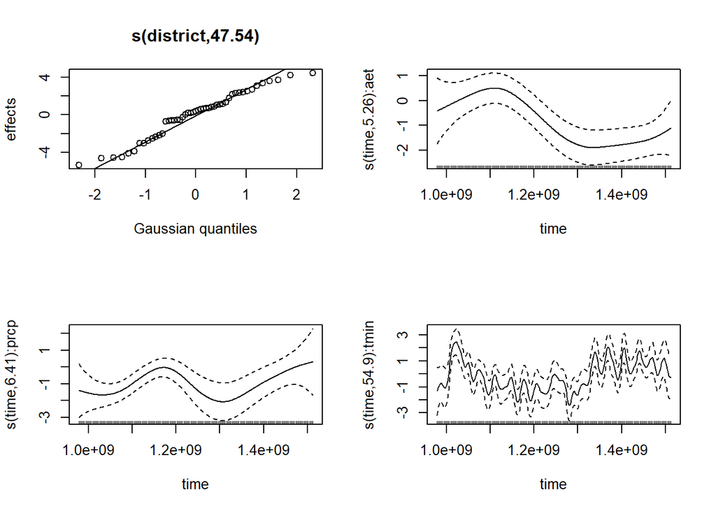

```r
mgcv::plot.gam(
  x          = falciparum_tvcm_5,
  n          = 500,
  seWithMean = TRUE,
  scale      = 0,
  pages      = 1
)
```

```r
mgcv::concurvity(falciparum_tvcm_5)
```

```
##          para s(district) s(time):aet s(time):prcp s(time):tmin
## worst       1   1.0000000   0.9812346    0.9594706    0.9914611
## observed    1   0.1062077   0.9655630    0.8980915    0.9406647
## estimate    1   0.0466636   0.9633930    0.9011599    0.9692142
```

```r
mgcv::concurvity(falciparum_tvcm_5, full = FALSE)$estimate
```

```
##                   para s(district) s(time):aet s(time):prcp s(time):tmin
## para         1.0000000  0.02040821   0.3305551    0.2968757    0.3318624
## s(district)  1.0000000  1.00000000   0.3319527    0.3106347    0.3383577
## s(time):aet  0.9670981  0.02058471   1.0000000    0.8038147    0.9397760
## s(time):prcp 0.8096382  0.01782830   0.7477630    1.0000000    0.8521792
## s(time):tmin 0.9693042  0.02163550   0.9527532    0.8775541    1.0000000
```

## TVCM: Model 6

Predictors: `aet`, `prcp`,`tmax`

### P. vivax

```r
tictoc::tic("GAM model fitting")
vivax_tvcm_6 <- mgcv::bam(
  formula =
    vivax ~
    offset(ln_pop2015) +
    s(district, bs = "re", k = 49) +
    s(time, by = aet,  bs = "tp", k = 50) +
    s(time, by = prcp, bs = "tp", k = 30) +
    s(time, by = tmax, bs = "tp", k = 100),
  family   = nb(),
  data     = train,
  method   = "fREML",
  discrete = TRUE
)
tictoc::toc()
```

```
## GAM model fitting: 2.42 sec elapsed
```

```r
cat("\nConverged?", vivax_tvcm_6$converged, "\n")
```

```
##
## Converged? TRUE
```

```r
mgcv::summary.gam(vivax_tvcm_6)
```

```
##
## Family: Negative Binomial(0.868)
## Link function: log
##
## Formula:
## vivax ~ offset(ln_pop2015) + s(district, bs = "re", k = 49) +
##     s(time, by = aet, bs = "tp", k = 50) + s(time, by = prcp,
##     bs = "tp", k = 30) + s(time, by = tmax, bs = "tp", k = 100)
##
## Parametric coefficients:
##             Estimate Std. Error t value Pr(>|t|)
## (Intercept)  -6.1404     0.3307  -18.57   <2e-16 ***
## ---
## Signif. codes:  0 '***' 0.001 '**' 0.01 '*' 0.05 '.' 0.1 ' ' 1
##
## Approximate significance of smooth terms:
##                 edf Ref.df       F p-value
## s(district)  47.802 49.000 233.990  <2e-16 ***
## s(time):aet  19.479 23.249  12.410  <2e-16 ***
## s(time):prcp  6.288  7.542   9.965  <2e-16 ***
## s(time):tmax 61.211 73.844   8.205  <2e-16 ***
## ---
## Signif. codes:  0 '***' 0.001 '**' 0.01 '*' 0.05 '.' 0.1 ' ' 1
##
## R-sq.(adj) =  0.488   Deviance explained = 68.7%
## fREML =  13025  Scale est. = 1         n = 8775
```

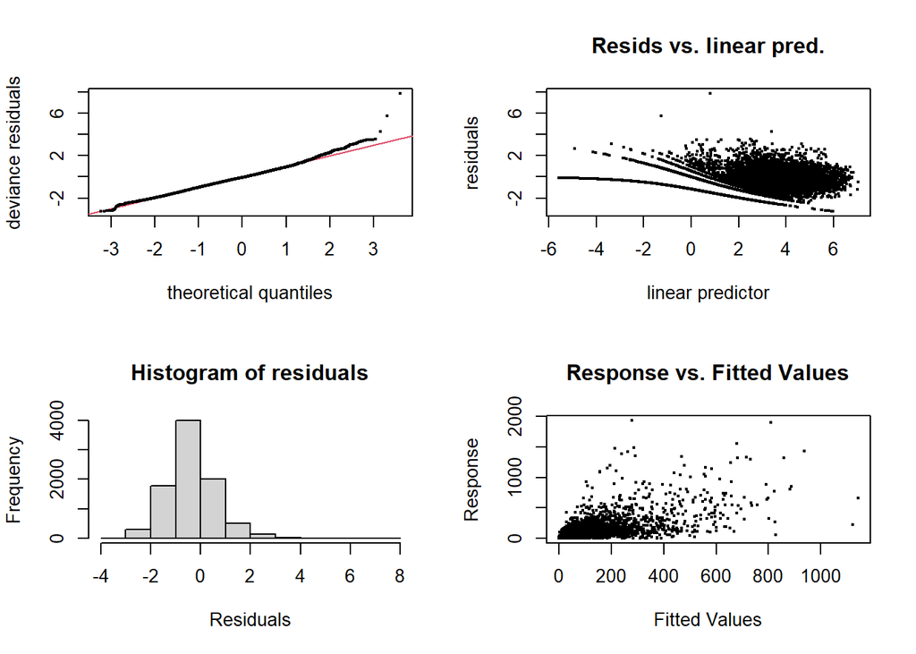

```
##
## Method: fREML   Optimizer: perf chol
## $grad
## [1] -4.798046e-10 -6.052844e-09 -1.919983e-09 -1.960286e-08
##
## $hess
##             [,1]        [,2]        [,3]        [,4]
## [1,] 23.31405927 -0.02066889 -0.01222222 -0.22571995
## [2,] -0.02066889  2.67212589  0.10525738  1.03010089
## [3,] -0.01222222  0.10525738  1.58312577  0.05553355
## [4,] -0.22571995  1.03010089  0.05553355 14.89793020
##
## Model rank =  230 / 230
##
## Basis dimension (k) checking results. Low p-value (k-index<1) may
## indicate that k is too low, especially if edf is close to k'.
##
##                  k'    edf k-index p-value
## s(district)   49.00  47.80      NA      NA
## s(time):aet   50.00  19.48    0.86    0.44
## s(time):prcp  30.00   6.29    0.86    0.45
## s(time):tmax 100.00  61.21    0.86    0.40
```

```r
par(mfrow = c(2, 2))
mgcv::gam.check(vivax_tvcm_6, pch = 19, cex = 0.3)
```

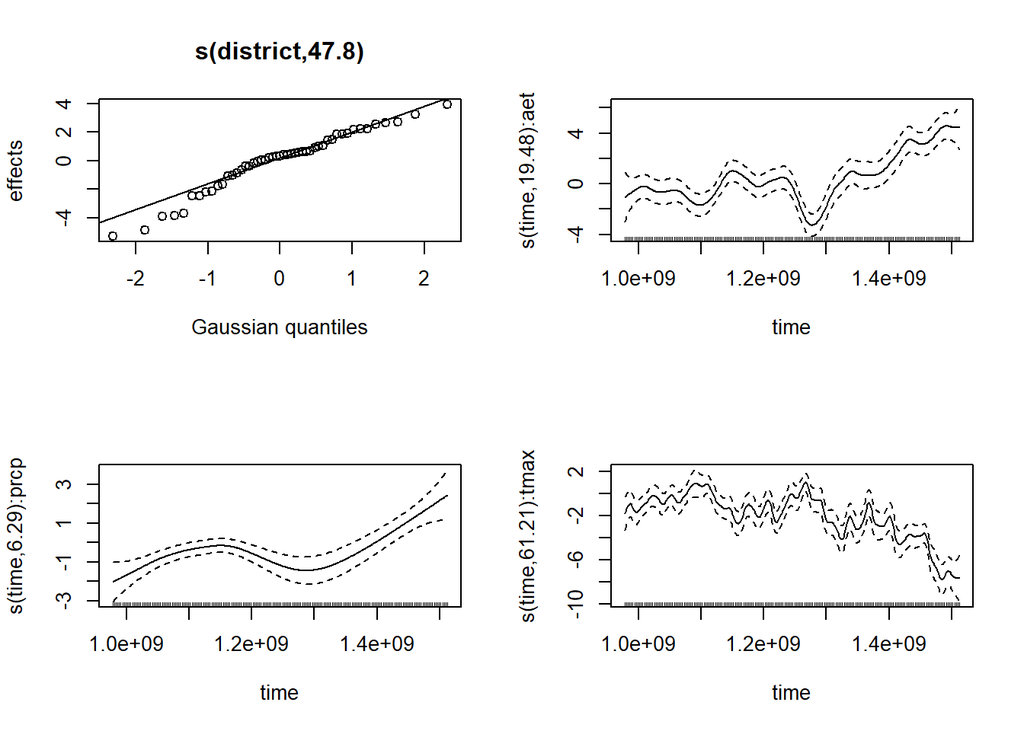

```r
mgcv::plot.gam(
  x          = vivax_tvcm_6,
  n          = 500,
  seWithMean = TRUE,
  scale      = 0,
  pages      = 1
)
```

```r
mgcv::concurvity(vivax_tvcm_6)
```

```
##          para s(district) s(time):aet s(time):prcp s(time):tmax
## worst       1   1.0000000   0.9838754    0.9387312    0.9943821
## observed    1   0.2887626   0.9641424    0.8741433    0.9763913
## estimate    1   0.0490043   0.9690801    0.8778184    0.9665660
```

```r
mgcv::concurvity(vivax_tvcm_6, full = FALSE)$estimate
```

```
##                   para s(district) s(time):aet s(time):prcp s(time):tmax
## para         1.0000000  0.02040821   0.3288669    0.2950191    0.3261908
## s(district)  1.0000000  1.00000000   0.3302587    0.3086795    0.3356939
## s(time):aet  0.9670981  0.02058471   1.0000000    0.8039619    0.9493636
## s(time):prcp 0.8096382  0.01782830   0.7477972    1.0000000    0.7661889
## s(time):tmax 0.9593073  0.02165244   0.9561661    0.8175272    1.0000000
```

### P. falciparum

```r
tictoc::tic("GAM model fitting")
falciparum_tvcm_6 <- mgcv::bam(
  formula =
    falciparum ~
    offset(ln_pop2015) +
    s(district, bs = "re", k = 49) +
    s(time, by = aet,  bs = "tp", k = 50) +
    s(time, by = prcp, bs = "tp", k = 30) +
    s(time, by = tmax, bs = "tp", k = 100),
  family   = nb(),
  data     = train,
  method   = "fREML",
  discrete = TRUE
)
tictoc::toc()
```

```
## GAM model fitting: 2.34 sec elapsed
```

```r
cat("\nConverged?", falciparum_tvcm_6$converged, "\n")
```

```
##
## Converged? TRUE
```

```r
mgcv::summary.gam(falciparum_tvcm_6)
```

```
##
## Family: Negative Binomial(0.509)
## Link function: log
##
## Formula:
## falciparum ~ offset(ln_pop2015) + s(district, bs = "re", k = 49) +
##     s(time, by = aet, bs = "tp", k = 50) + s(time, by = prcp,
##     bs = "tp", k = 30) + s(time, by = tmax, bs = "tp", k = 100)
##
## Parametric coefficients:
##             Estimate Std. Error t value Pr(>|t|)
## (Intercept)  -7.3336     0.3941  -18.61   <2e-16 ***
## ---
## Signif. codes:  0 '***' 0.001 '**' 0.01 '*' 0.05 '.' 0.1 ' ' 1
##
## Approximate significance of smooth terms:
##                 edf Ref.df       F p-value
## s(district)  47.497 48.000 149.982  <2e-16 ***
## s(time):aet   7.833  9.413  10.286  <2e-16 ***
## s(time):prcp  8.172  9.843   9.781  <2e-16 ***
## s(time):tmax 53.533 65.357   5.895  <2e-16 ***
## ---
## Signif. codes:  0 '***' 0.001 '**' 0.01 '*' 0.05 '.' 0.1 ' ' 1
##
## R-sq.(adj) =  0.338   Deviance explained = 65.2%
## fREML =  12086  Scale est. = 1         n = 8775
```

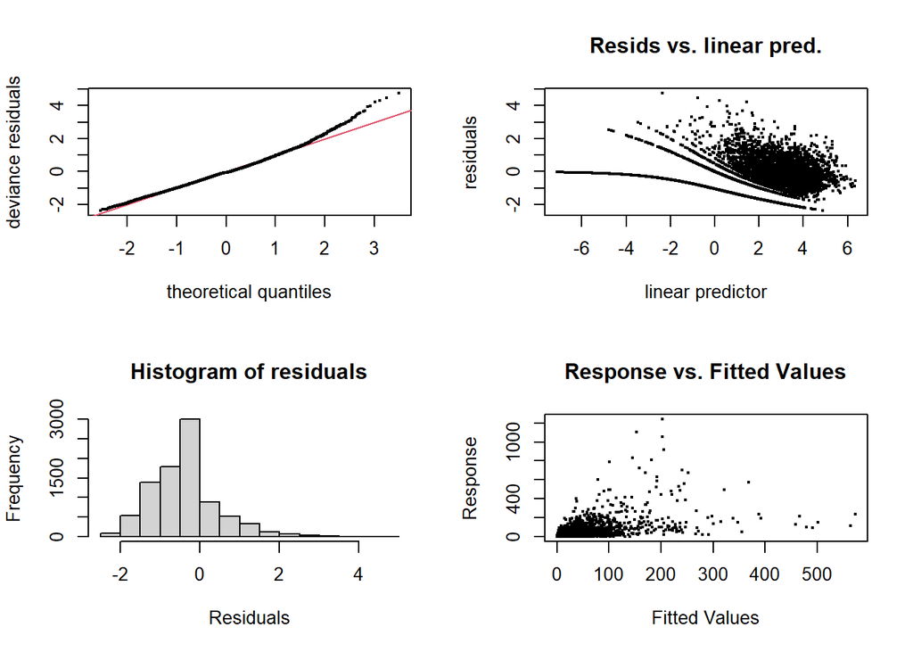

```
##
## Method: fREML   Optimizer: perf chol
## $grad
## [1] 1.435248e-08 1.726415e-08 2.632960e-08 2.534918e-07
##
## $hess
##               [,1]        [,2]          [,3]         [,4]
## [1,] 22.6021810359  0.01148264 -0.0006141904 -0.152561778
## [2,]  0.0114826365  1.26832206  0.1743055288 -0.140665217
## [3,] -0.0006141904  0.17430553  1.2341008107 -0.008191668
## [4,] -0.1525617785 -0.14066522 -0.0081916682  9.475639639
##
## Model rank =  230 / 230
##
## Basis dimension (k) checking results. Low p-value (k-index<1) may
## indicate that k is too low, especially if edf is close to k'.
##
##                  k'    edf k-index p-value
## s(district)   49.00  47.50      NA      NA
## s(time):aet   50.00   7.83    0.83    0.75
## s(time):prcp  30.00   8.17    0.83    0.78
## s(time):tmax 100.00  53.53    0.83    0.79
```

```r
par(mfrow = c(2, 2))
mgcv::gam.check(falciparum_tvcm_6, pch = 19, cex = 0.3)
```

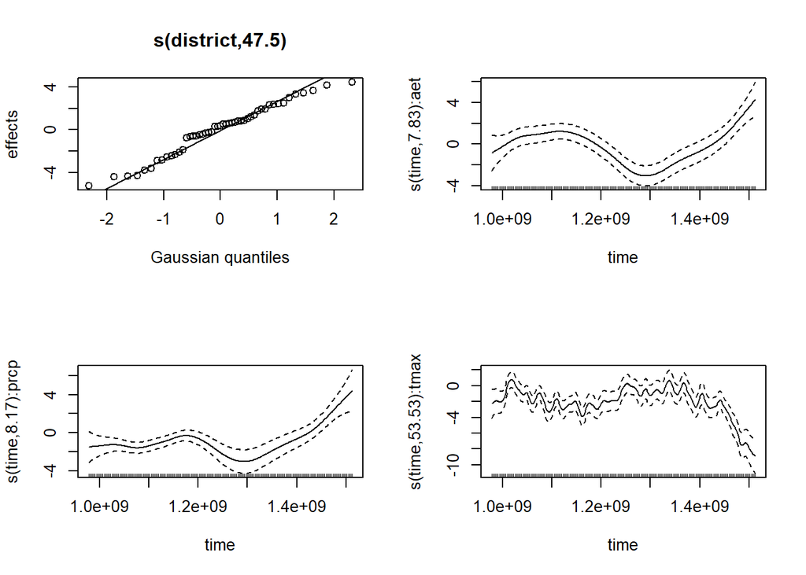

```r
mgcv::plot.gam(
  x          = falciparum_tvcm_6,
  n          = 500,
  seWithMean = TRUE,
  scale      = 0,
  pages      = 1
)
```

```r
mgcv::concurvity(falciparum_tvcm_6)
```

```
##          para s(district) s(time):aet s(time):prcp s(time):tmax
## worst       1   1.0000000   0.9838754    0.9387312    0.9943821
## observed    1   0.3064720   0.9601912    0.8835366    0.9771873
## estimate    1   0.0490043   0.9691168    0.8779189    0.9666397
```

```r
mgcv::concurvity(falciparum_tvcm_6, full = FALSE)$estimate
```

```
##                   para s(district) s(time):aet s(time):prcp s(time):tmax
## para         1.0000000  0.02040821   0.3313619    0.2976936    0.3284627
## s(district)  1.0000000  1.00000000   0.3327625    0.3115038    0.3380444
## s(time):aet  0.9670981  0.02058471   1.0000000    0.8037122    0.9493202
## s(time):prcp 0.8096382  0.01782830   0.7477378    1.0000000    0.7661190
## s(time):tmax 0.9593073  0.02165244   0.9561287    0.8172617    1.0000000
```

## TVCM: Model 7

Predictors: `q`, `tmin`

### P. vivax

```r
tictoc::tic("GAM model fitting")
vivax_tvcm_7 <- mgcv::bam(
  formula =
    vivax ~
    offset(ln_pop2015) +
    s(district, bs = "re", k = 49) +
    s(time, by = q,    bs = "tp", k = 30) +
    s(time, by = tmin, bs = "tp", k = 100),
  family   = nb(),
  data     = train,
  method   = "fREML",
  discrete = TRUE
)
tictoc::toc()
```

```
## GAM model fitting: 1.91 sec elapsed
```

```r
cat("\nConverged?", vivax_tvcm_7$converged, "\n")
```

```
##
## Converged? TRUE
```

```r
mgcv::summary.gam(vivax_tvcm_7)
```

```
##
## Family: Negative Binomial(0.833)
## Link function: log
##
## Formula:
## vivax ~ offset(ln_pop2015) + s(district, bs = "re", k = 49) +
##     s(time, by = q, bs = "tp", k = 30) + s(time, by = tmin, bs = "tp",
##     k = 100)
##
## Parametric coefficients:
##             Estimate Std. Error t value Pr(>|t|)
## (Intercept)  -6.8260     0.3291  -20.74   <2e-16 ***
## ---
## Signif. codes:  0 '***' 0.001 '**' 0.01 '*' 0.05 '.' 0.1 ' ' 1
##
## Approximate significance of smooth terms:
##                 edf Ref.df       F p-value
## s(district)  47.820 48.000 266.888 < 2e-16 ***
## s(time):q     4.544  5.422   3.645 0.00268 **
## s(time):tmin 68.271 80.919  17.678 < 2e-16 ***
## ---
## Signif. codes:  0 '***' 0.001 '**' 0.01 '*' 0.05 '.' 0.1 ' ' 1
##
## R-sq.(adj) =  0.482   Deviance explained = 67.5%
## fREML =  13017  Scale est. = 1         n = 8775
```

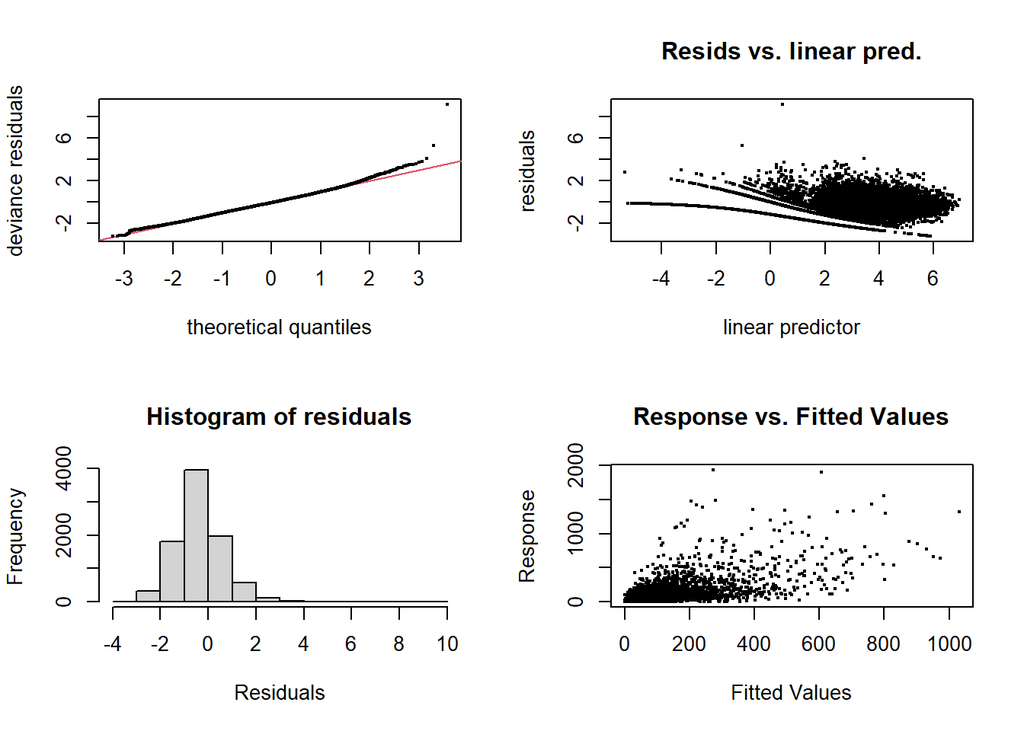

```
##
## Method: fREML   Optimizer: perf chol
## $grad
## [1] 5.277639e-08 3.291232e-08 7.456945e-07
##
## $hess
##              [,1]         [,2]        [,3]
## [1,] 23.422668025 -0.003346154 -0.08832332
## [2,] -0.003346154  0.564715272  0.08215081
## [3,] -0.088323324  0.082150811 22.60828917
##
## Model rank =  180 / 180
##
## Basis dimension (k) checking results. Low p-value (k-index<1) may
## indicate that k is too low, especially if edf is close to k'.
##
##                  k'    edf k-index p-value
## s(district)   49.00  47.82      NA      NA
## s(time):q     30.00   4.54    0.85    0.10
## s(time):tmin 100.00  68.27    0.85    0.14
```

```r
par(mfrow = c(2, 2))
mgcv::gam.check(vivax_tvcm_7, pch = 19, cex = 0.3)
```

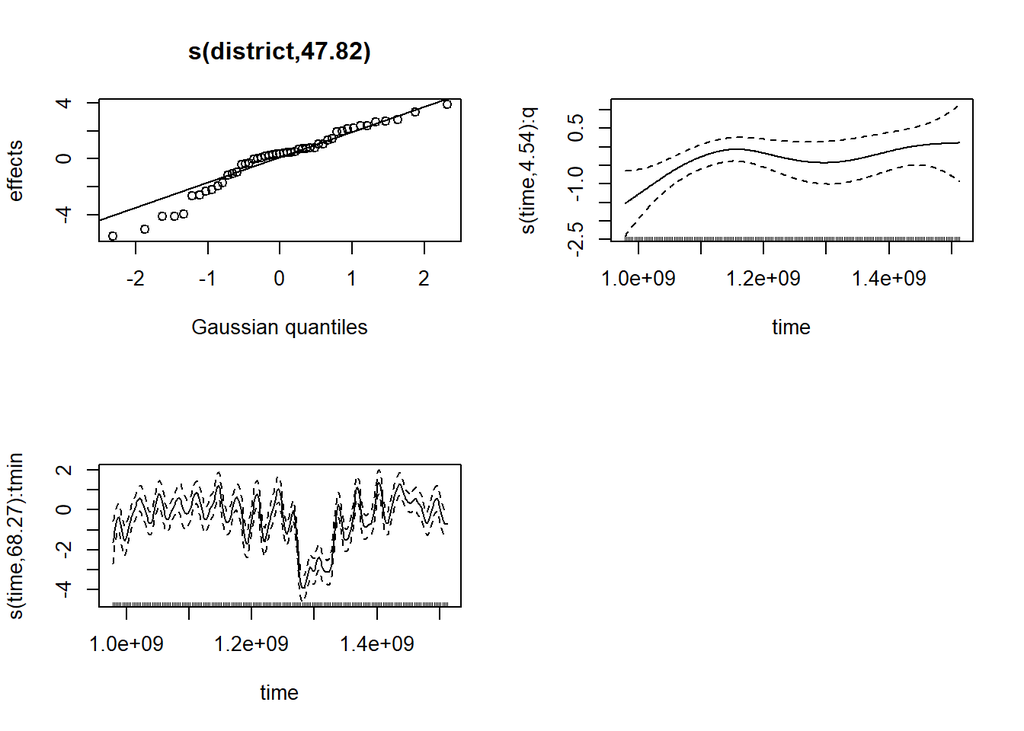

```r
mgcv::plot.gam(
  x          = vivax_tvcm_7,
  n          = 500,
  seWithMean = TRUE,
  scale      = 0,
  pages      = 1
)
```

```r
mgcv::concurvity(vivax_tvcm_7)
```

```
##          para s(district) s(time):q s(time):tmin
## worst       1  1.00000000 0.8859850    0.9888265
## observed    1  0.13080113 0.7882154    0.5108605
## estimate    1  0.04081106 0.8082241    0.7998540
```

```r
mgcv::concurvity(vivax_tvcm_7, full = FALSE)$estimate
```

```
##                   para s(district) s(time):q s(time):tmin
## para         1.0000000  0.02040821 0.2379314    0.3335221
## s(district)  1.0000000  1.00000000 0.2644527    0.3400443
## s(time):q    0.6426163  0.01516121 1.0000000    0.7091891
## s(time):tmin 0.9693042  0.02163550 0.7823807    1.0000000
```

### P. falciparum

```r
tictoc::tic("GAM model fitting")
falciparum_tvcm_7 <- mgcv::bam(
  formula =
    falciparum ~
    offset(ln_pop2015) +
    s(district, bs = "re", k = 49) +
    s(time, by = q,    bs = "tp", k = 30) +
    s(time, by = tmin, bs = "tp", k = 100),
  family   = nb(),
  data     = train,
  method   = "fREML",
  discrete = TRUE
)
tictoc::toc()
```

```
## GAM model fitting: 2.31 sec elapsed
```

```r
cat("\nConverged?", falciparum_tvcm_7$converged, "\n")
```

```
##
## Converged? TRUE
```

```r
mgcv::summary.gam(falciparum_tvcm_7)
```

```
##
## Family: Negative Binomial(0.496)
## Link function: log
##
## Formula:
## falciparum ~ offset(ln_pop2015) + s(district, bs = "re", k = 49) +
##     s(time, by = q, bs = "tp", k = 30) + s(time, by = tmin, bs = "tp",
##     k = 100)
##
## Parametric coefficients:
##             Estimate Std. Error t value Pr(>|t|)
## (Intercept)  -8.3464     0.3891  -21.45   <2e-16 ***
## ---
## Signif. codes:  0 '***' 0.001 '**' 0.01 '*' 0.05 '.' 0.1 ' ' 1
##
## Approximate significance of smooth terms:
##                 edf Ref.df       F p-value
## s(district)  47.540 48.000 162.367  <2e-16 ***
## s(time):q     6.742  8.114   6.416  <2e-16 ***
## s(time):tmin 55.938 67.892  10.680  <2e-16 ***
## ---
## Signif. codes:  0 '***' 0.001 '**' 0.01 '*' 0.05 '.' 0.1 ' ' 1
##
## R-sq.(adj) =   0.36   Deviance explained = 64.3%
## fREML =  12093  Scale est. = 1         n = 8775
```

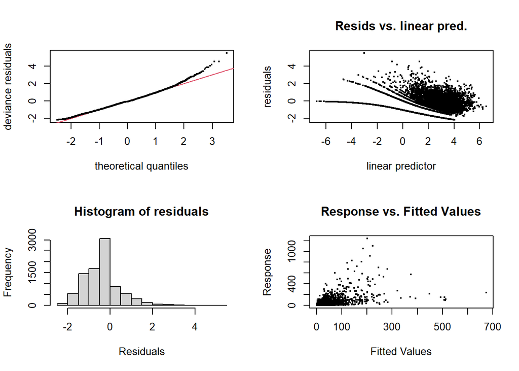

```
##
## Method: fREML   Optimizer: perf chol
## $grad
## [1] 7.726640e-07 1.950837e-07 2.017161e-06
##
## $hess
##              [,1]         [,2]        [,3]
## [1,] 22.802779092 -0.001092576 -0.07579328
## [2,] -0.001092576  1.207391630 -0.41939787
## [3,] -0.075793284 -0.419397875 13.77709182
##
## Model rank =  180 / 180
##
## Basis dimension (k) checking results. Low p-value (k-index<1) may
## indicate that k is too low, especially if edf is close to k'.
##
##                  k'    edf k-index p-value
## s(district)   49.00  47.54      NA      NA
## s(time):q     30.00   6.74     0.8    0.17
## s(time):tmin 100.00  55.94     0.8    0.15
```

```r
par(mfrow = c(2, 2))
mgcv::gam.check(falciparum_tvcm_7, pch = 19, cex = 0.3)
```

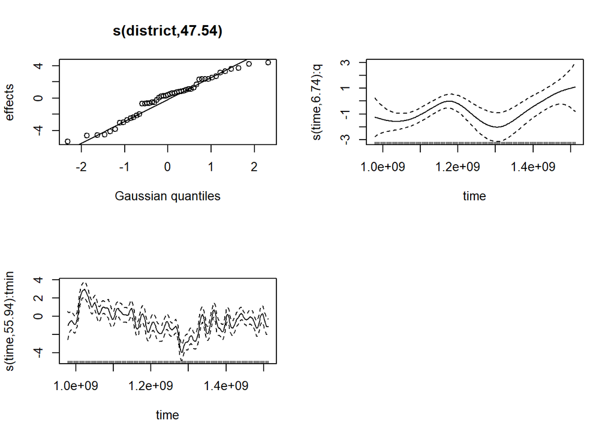

```r
mgcv::plot.gam(
  x          = falciparum_tvcm_7,
  n          = 500,
  seWithMean = TRUE,
  scale      = 0,
  pages      = 1
)
```

```r
mgcv::concurvity(falciparum_tvcm_7)
```

```
##          para s(district) s(time):q s(time):tmin
## worst       1  1.00000000 0.8859850    0.9888265
## observed    1  0.09480308 0.7897435    0.5870390
## estimate    1  0.04081106 0.8080373    0.7986906
```

```r
mgcv::concurvity(falciparum_tvcm_7, full = FALSE)$estimate
```

```
##                   para s(district) s(time):q s(time):tmin
## para         1.0000000  0.02040821 0.2350157    0.3295195
## s(district)  1.0000000  1.00000000 0.2611375    0.3359766
## s(time):q    0.6426163  0.01516121 1.0000000    0.7091196
## s(time):tmin 0.9693042  0.02163550 0.7825829    1.0000000
```